# MT Code Result Analysis 07

Markus Rottmann

2021 05 11

#### Description

This Code is to analyze/build the results from the simulating each countermeasure (in NetLogo). It calculates descriptive statistics, renders plots and performs OLS.  
The settings for the simulation runs are:

- 10 initial information pollution tweets.
- 7 days of tweet life-span (ip-tweet is not recognized as such after 7 days).
- 365 days of simulation.

**Input**

**Output**

- `ols_warn_noip10_lstwt07_365_real_02.html`: OLS results for real-life network for countermeasure *warning label*.
- `ols_warn_noip10_lstwt07_365_sim_02.html`: OLS results for artificial networks for countermeasure *warning label*.
- `plt_warn_noip10_lstwt07_real_allobs_01.png`: plot ip-tweets vs. countermeasure strength of real-life network for countermeasure *warning label*.
- `plt_warn_noip10_lstwt07_artif_365_01.png`: plot ip-tweets vs. countermeasure strength of artificial networks, only those simulation runs that reach 365 days for countermeasure *warning label*.
- `plt_warn_noip10_lstwt07_all_allobs_01.png`: plot ip-tweets vs. countermeasure strength of all networks and all runs for countermeasure *warning label*.
- `ols_susp_noip10_lstwt07_365_real_02.html`: OLS results for real-life network for countermeasure *account suspension*.
- `ols_susp_noip10_lstwt07_365_sim_02.html`: OLS results for artificial networks for countermeasure *account suspension*.
- `plt_susp_noip10_lstwt07_real_allobs_01.png`: plot ip-tweets vs. countermeasure strength of real-life network for countermeasure *account suspension*.
- `plt_susp_noip10_lstwt07_artif_365_01.png`: plot ip-tweets vs. countermeasure strength of artificial networks, only those simulation runs that reach 365 days for countermeasure *account suspension*.
- `plt_susp_noip10_lstwt07_all_allobs_01.png`: plot ip-tweets vs. countermeasure strength of all networks and all runs for countermeasure *account suspension*.
- `ols_ban_noip10_lstwt07_365_real_02.html`: OLS results for real-life network for countermeasure *account ban*.
- `ols_ban_noip10_lstwt07_365_sim_02.html`: OLS results for artificial networks for countermeasure *account ban*.
- `plt_ban_noip10_lstwt07_real_allobs_01.png`: plot ip-tweets vs. countermeasure strength of real-life network for countermeasure *account ban*.
- `plt_ban_noip10_lstwt07_artif_365_01.png`: plot ip-tweets vs. countermeasure strength of artificial networks, only those simulation runs that reach 365 days for countermeasure *account ban*.
- `plt_ban_noip10_lstwt07_all_allobs_01.png`: plot ip-tweets vs. countermeasure strength of all networks and all runs for countermeasure *account ban*.

#### 1. Contermeasure “Warning”

16 x ~20 Runs are performed. Settings for these simulation runs are:

- Real-life network with 858 members, average node density = 30
  - Run 1: 0% lowering of probability to post an IP Tweet.
  - Run 2: 25% lowering of probability to post an IP Tweet.
  - Run 3: 50% lowering of probability to post an IP Tweet.
  - Run 4: 75% lowering of probability to post an IP Tweet.
- Simulated Network with 858 members, average node density = 15
  - Run 1: 0% lowering of probability to post an IP Tweet.
  - Run 2: 25% lowering of probability to post an IP Tweet.
  - Run 3: 50% lowering of probability to post an IP Tweet.
  - Run 4: 75% lowering of probability to post an IP Tweet.
- Simulated Network with 858 members, average node density = 30
  - Run 1: 0% lowering of probability to post an IP Tweet.
  - Run 2: 25% lowering of probability to post an IP Tweet.
  - Run 3: 50% lowering of probability to post an IP Tweet.
  - Run 4: 75% lowering of probability to post an IP Tweet.
- Simulated Network with 858 members, average node density = 45
  - Run 1: 0% lowering of probability to post an IP Tweet.
  - Run 2: 25% lowering of probability to post an IP Tweet.
  - Run 3: 50% lowering of probability to post an IP Tweet.
  - Run 4: 75% lowering of probability to post an IP Tweet.

##### 1.1 Data Preparation

```r
#### Loading Data & Preparing data
data00 <- read.csv2(file = "./RawData/network_sim_warn_02_04_noip10_lstwt7_365_01.csv") %>%
  `colnames<-`(c("p_warn", "dens", "descr", "val"))

## Brining data in wide format, adding ticks and turtles to same observation ---------------
# getting number of rows
n_row <- nrow(data00) # number of rows
# making vector with run-ids (3 values per run)
vct00 <- rep(x = (1:(n_row/3)) , times = 3) %>%
  as.numeric(.) %>%
  sort(.)
# attaching vector to data00 and spread (from long to wide format)
data01 <- data00 %>%
  cbind(., run_id = vct00) %>%
  spread(., key = c("descr"), value = "val") %>%
  dplyr::select(., run_id, p_warn, dens, sum_newip, sum_trltls, ticks)
# saving wide format observations
data01 %>%
   saveRDS(., file = "./RawData/nw_sim_warn_noip10_ls7_356_wide_01.RDS")

## First Plot of Results "Warning"
# with all observations (including those stopping before 365 days)
data02 <- data01 %>%
          group_by(p_warn, dens) %>%
          summarize(mn_newip = mean(sum_newip), sd_newip = sd(sum_newip))
# only observatons that ran to 365 days
data03 <- data01 %>%
          filter(., ticks == 365) %>%
          group_by(p_warn, dens) %>%
          summarize(mn_newip = mean(sum_newip), sd_newip = sd(sum_newip))
```

##### 1.2 Descriptive and OLS

```r
#### calculating Descriptive -------------------------------------------------------------------
## Numbers of ticks for all rounds
# calculating
res_d00 <- data01 %>%
  group_by(., p_warn, dens) %>%
  summarize(mean = mean(ticks))
# showing
res_d00
```

```
## # A tibble: 16 x 3
## # Groups:   p_warn [4]
##    p_warn dens    mean
##     <int> <chr>  <dbl>
##  1      0 real   365
##  2      0 sim_15 365
##  3      0 sim_30 365
##  4      0 sim_45 365
##  5     25 real   365
##  6     25 sim_15 365
##  7     25 sim_30 365
##  8     25 sim_45 365
##  9     50 real   365
## 10     50 sim_15  37.6
## 11     50 sim_30 360.
## 12     50 sim_45 365
## 13     75 real   104.
## 14     75 sim_15  15.4
## 15     75 sim_30  34.8
## 16     75 sim_45 135.
```

```r
#### performing OLS -------------------------------------------------------------------

## for network density "real" ----------
# all observations
res01a <- data01 %>%
         filter(., dens %in% "real") %>%
         lm(data = ., formula = sum_newip ~ p_warn)
summary(res01a)
```

```
##
## Call:
## lm(formula = sum_newip ~ p_warn, data = .)
##
## Residuals:
##      Min       1Q   Median       3Q      Max
## -215.677  -66.270    0.323   66.261  196.261
##
## Coefficients:
##              Estimate Std. Error t value Pr(>|t|)
## (Intercept) 3308.6767    14.9287   221.6   <2e-16 ***
## p_warn       -42.1388     0.3056  -137.9   <2e-16 ***
## ---
## Signif. codes:  0 '***' 0.001 '**' 0.01 '*' 0.05 '.' 0.1 ' ' 1
##
## Residual standard error: 84.62 on 91 degrees of freedom
## Multiple R-squared:  0.9952, Adjusted R-squared:  0.9952
## F-statistic: 1.901e+04 on 1 and 91 DF,  p-value: < 2.2e-16
```

```r
# observations that ran for 365 days
res01b <- data01 %>%
         filter(., ticks == 365) %>%
         filter(., dens %in% "real") %>%
         lm(data = ., formula = sum_newip ~ p_warn)
summary(res01b)
```

```
##
## Call:
## lm(formula = sum_newip ~ p_warn, data = .)
##
## Residuals:
##      Min       1Q   Median       3Q      Max
## -187.597  -41.542   -4.542   35.115  211.403
##
## Coefficients:
##              Estimate Std. Error t value Pr(>|t|)
## (Intercept) 3280.5968    13.6487  240.36   <2e-16 ***
## p_warn       -40.4148     0.4191  -96.43   <2e-16 ***
## ---
## Signif. codes:  0 '***' 0.001 '**' 0.01 '*' 0.05 '.' 0.1 ' ' 1
##
## Residual standard error: 71.06 on 64 degrees of freedom
## Multiple R-squared:  0.9932, Adjusted R-squared:  0.9931
## F-statistic:  9299 on 1 and 64 DF,  p-value: < 2.2e-16
```

```r
# observations that ran for 365 days & between point 0 & 1
res01b_0_1 <- data01 %>%
         filter(., ticks == 365) %>%
         filter(., dens %in% "real") %>%
         filter(., p_warn == 0 | p_warn == 25) %>%
         lm(data = ., formula = sum_newip ~ p_warn)
summary(res01b_0_1)
```

```
##
## Call:
## lm(formula = sum_newip ~ p_warn, data = .)
##
## Residuals:
##     Min      1Q  Median      3Q     Max
## -197.96  -53.96    2.60   49.54  201.04
##
## Coefficients:
##              Estimate Std. Error t value Pr(>|t|)
## (Intercept) 3290.9565    16.0077   205.6   <2e-16 ***
## p_warn       -41.7823     0.9389   -44.5   <2e-16 ***
## ---
## Signif. codes:  0 '***' 0.001 '**' 0.01 '*' 0.05 '.' 0.1 ' ' 1
##
## Residual standard error: 76.77 on 41 degrees of freedom
## Multiple R-squared:  0.9797, Adjusted R-squared:  0.9792
## F-statistic:  1980 on 1 and 41 DF,  p-value: < 2.2e-16
```

```r
# observations that ran for 365 days & between point 1 & 2
res01b_1_2 <- data01 %>%
         filter(., ticks == 365) %>%
         filter(., dens %in% "real") %>%
         filter(., p_warn == 25 | p_warn == 50) %>%
         lm(data = ., formula = sum_newip ~ p_warn)
summary(res01b_1_2)
```

```
##
## Call:
## lm(formula = sum_newip ~ p_warn, data = .)
##
## Residuals:
##      Min       1Q   Median       3Q      Max
## -106.400  -42.717    0.783   26.783  145.600
##
## Coefficients:
##              Estimate Std. Error t value Pr(>|t|)
## (Intercept) 3222.5826    29.9143  107.73   <2e-16 ***
## p_warn       -39.0473     0.7414  -52.67   <2e-16 ***
## ---
## Signif. codes:  0 '***' 0.001 '**' 0.01 '*' 0.05 '.' 0.1 ' ' 1
##
## Residual standard error: 60.62 on 41 degrees of freedom
## Multiple R-squared:  0.9854, Adjusted R-squared:  0.9851
## F-statistic:  2774 on 1 and 41 DF,  p-value: < 2.2e-16
```

```r
# # observations that ran for 365 days & between point 0 & 2
res01b_0_2 <- data01 %>%
         filter(., ticks == 365) %>%
         filter(., dens %in% "real") %>%
         filter(., p_warn == 0 | p_warn == 25 | p_warn == 50) %>%
         lm(data = ., formula = sum_newip ~ p_warn)
summary(res01b_0_2)
```

```
##
## Call:
## lm(formula = sum_newip ~ p_warn, data = .)
##
## Residuals:
##      Min       1Q   Median       3Q      Max
## -187.597  -41.542   -4.542   35.115  211.403
##
## Coefficients:
##              Estimate Std. Error t value Pr(>|t|)
## (Intercept) 3280.5968    13.6487  240.36   <2e-16 ***
## p_warn       -40.4148     0.4191  -96.43   <2e-16 ***
## ---
## Signif. codes:  0 '***' 0.001 '**' 0.01 '*' 0.05 '.' 0.1 ' ' 1
##
## Residual standard error: 71.06 on 64 degrees of freedom
## Multiple R-squared:  0.9932, Adjusted R-squared:  0.9931
## F-statistic:  9299 on 1 and 64 DF,  p-value: < 2.2e-16
```

```r
## for network density "sim_15" ----------
# all observations
res02a <- data01 %>%
         filter(., dens %in% "sim_15") %>%
         lm(data = ., formula = sum_newip ~ p_warn)
summary(res02a)
```

```
##
## Call:
## lm(formula = sum_newip ~ p_warn, data = .)
##
## Residuals:
##    Min     1Q Median     3Q    Max
## -692.2 -455.4  168.0  476.9  678.5
##
## Coefficients:
##             Estimate Std. Error t value Pr(>|t|)
## (Intercept) 3028.493     84.038   36.04   <2e-16 ***
## p_warn       -46.685      1.778  -26.26   <2e-16 ***
## ---
## Signif. codes:  0 '***' 0.001 '**' 0.01 '*' 0.05 '.' 0.1 ' ' 1
##
## Residual standard error: 489.9 on 92 degrees of freedom
## Multiple R-squared:  0.8823, Adjusted R-squared:  0.881
## F-statistic: 689.4 on 1 and 92 DF,  p-value: < 2.2e-16
```

```r
# observations that ran for 365 days
res02b <- data01 %>%
         filter(., ticks == 365) %>%
         filter(., dens %in% "sim_15") %>%
         lm(data = ., formula = sum_newip ~ p_warn)
summary(res02b)
```

```
##
## Call:
## lm(formula = sum_newip ~ p_warn, data = .)
##
## Residuals:
##    Min     1Q Median     3Q    Max
## -280.7 -106.5   -9.0  112.2  295.3
##
## Coefficients:
##             Estimate Std. Error t value Pr(>|t|)
## (Intercept) 3423.000     29.876  114.57   <2e-16 ***
## p_warn       -74.574      1.708  -43.65   <2e-16 ***
## ---
## Signif. codes:  0 '***' 0.001 '**' 0.01 '*' 0.05 '.' 0.1 ' ' 1
##
## Residual standard error: 146.4 on 45 degrees of freedom
## Multiple R-squared:  0.9769, Adjusted R-squared:  0.9764
## F-statistic:  1906 on 1 and 45 DF,  p-value: < 2.2e-16
```

```r
# observations that ran for 365 days & between point 0 & 1
res02b_0_1 <- data01 %>%
         filter(., ticks == 365) %>%
         filter(., dens %in% "sim_15") %>%
         filter(., p_warn == 0 | p_warn == 25) %>%
         lm(data = ., formula = sum_newip ~ p_warn)
summary(res02b_0_1)
```

```
##
## Call:
## lm(formula = sum_newip ~ p_warn, data = .)
##
## Residuals:
##    Min     1Q Median     3Q    Max
## -280.7 -106.5   -9.0  112.2  295.3
##
## Coefficients:
##             Estimate Std. Error t value Pr(>|t|)
## (Intercept) 3423.000     29.876  114.57   <2e-16 ***
## p_warn       -74.574      1.708  -43.65   <2e-16 ***
## ---
## Signif. codes:  0 '***' 0.001 '**' 0.01 '*' 0.05 '.' 0.1 ' ' 1
##
## Residual standard error: 146.4 on 45 degrees of freedom
## Multiple R-squared:  0.9769, Adjusted R-squared:  0.9764
## F-statistic:  1906 on 1 and 45 DF,  p-value: < 2.2e-16
```

```r
## for network density "sim_30" ----------
# all observations
res03a <- data01 %>%
         filter(., dens %in% "sim_30") %>%
         lm(data = ., formula = sum_newip ~ p_warn)
summary(res03a)
```

```
##
## Call:
## lm(formula = sum_newip ~ p_warn, data = .)
##
## Residuals:
##     Min      1Q  Median      3Q     Max
## -751.44  -64.77  -28.27   86.40  323.90
##
## Coefficients:
##             Estimate Std. Error t value Pr(>|t|)
## (Intercept) 4829.767     22.031   219.2   <2e-16 ***
## p_warn       -63.307      0.465  -136.1   <2e-16 ***
## ---
## Signif. codes:  0 '***' 0.001 '**' 0.01 '*' 0.05 '.' 0.1 ' ' 1
##
## Residual standard error: 135.3 on 108 degrees of freedom
## Multiple R-squared:  0.9942, Adjusted R-squared:  0.9942
## F-statistic: 1.853e+04 on 1 and 108 DF,  p-value: < 2.2e-16
```

```r
# observations that ran for 365 days
res03b <- data01 %>%
         filter(., ticks == 365) %>%
         filter(., dens %in% "sim_30") %>%
         lm(data = ., formula = sum_newip ~ p_warn)
summary(res03b)
```

```
##
## Call:
## lm(formula = sum_newip ~ p_warn, data = .)
##
## Residuals:
##     Min      1Q  Median      3Q     Max
## -338.24  -84.73    7.27   84.76  297.27
##
## Coefficients:
##              Estimate Std. Error t value Pr(>|t|)
## (Intercept) 4786.2181    19.9497  239.91   <2e-16 ***
## p_warn       -60.4996     0.6092  -99.32   <2e-16 ***
## ---
## Signif. codes:  0 '***' 0.001 '**' 0.01 '*' 0.05 '.' 0.1 ' ' 1
##
## Residual standard error: 111.9 on 79 degrees of freedom
## Multiple R-squared:  0.9921, Adjusted R-squared:  0.992
## F-statistic:  9864 on 1 and 79 DF,  p-value: < 2.2e-16
```

```r
# observations that ran for 365 days & between point 0 & 1
res03b_0_1 <- data01 %>%
         filter(., ticks == 365) %>%
         filter(., dens %in% "sim_30") %>%
         filter(., p_warn == 0 | p_warn == 25) %>%
         lm(data = ., formula = sum_newip ~ p_warn)
summary(res03b_0_1)
```

```
##
## Call:
## lm(formula = sum_newip ~ p_warn, data = .)
##
## Residuals:
##      Min       1Q   Median       3Q      Max
## -216.815  -61.815    4.185   80.185  228.185
##
## Coefficients:
##             Estimate Std. Error t value Pr(>|t|)
## (Intercept) 4750.346     19.535  243.17   <2e-16 ***
## p_warn       -56.301      1.095  -51.43   <2e-16 ***
## ---
## Signif. codes:  0 '***' 0.001 '**' 0.01 '*' 0.05 '.' 0.1 ' ' 1
##
## Residual standard error: 99.61 on 51 degrees of freedom
## Multiple R-squared:  0.9811, Adjusted R-squared:  0.9807
## F-statistic:  2645 on 1 and 51 DF,  p-value: < 2.2e-16
```

```r
# observations that ran for 365 days & between point 1 & 2
res03b_1_2 <- data01 %>%
         filter(., ticks == 365) %>%
         filter(., dens %in% "sim_30") %>%
         filter(., p_warn == 25 | p_warn == 50) %>%
         lm(data = ., formula = sum_newip ~ p_warn)
summary(res03b_1_2)
```

```
##
## Call:
## lm(formula = sum_newip ~ p_warn, data = .)
##
## Residuals:
##     Min      1Q  Median      3Q     Max
## -304.93  -61.37   14.07   87.63  228.19
##
## Coefficients:
##             Estimate Std. Error t value Pr(>|t|)
## (Intercept) 4957.701     46.343   107.0   <2e-16 ***
## p_warn       -64.595      1.166   -55.4   <2e-16 ***
## ---
## Signif. codes:  0 '***' 0.001 '**' 0.01 '*' 0.05 '.' 0.1 ' ' 1
##
## Residual standard error: 108.1 on 53 degrees of freedom
## Multiple R-squared:  0.983,  Adjusted R-squared:  0.9827
## F-statistic:  3069 on 1 and 53 DF,  p-value: < 2.2e-16
```

```r
# # observations that ran for 365 days & between point 0 & 2
res03b_0_2 <- data01 %>%
         filter(., ticks == 365) %>%
         filter(., dens %in% "sim_30") %>%
         filter(., p_warn == 0 | p_warn == 25 | p_warn == 50) %>%
         lm(data = ., formula = sum_newip ~ p_warn)
summary(res03b_0_2)
```

```
##
## Call:
## lm(formula = sum_newip ~ p_warn, data = .)
##
## Residuals:
##     Min      1Q  Median      3Q     Max
## -338.24  -84.73    7.27   84.76  297.27
##
## Coefficients:
##              Estimate Std. Error t value Pr(>|t|)
## (Intercept) 4786.2181    19.9497  239.91   <2e-16 ***
## p_warn       -60.4996     0.6092  -99.32   <2e-16 ***
## ---
## Signif. codes:  0 '***' 0.001 '**' 0.01 '*' 0.05 '.' 0.1 ' ' 1
##
## Residual standard error: 111.9 on 79 degrees of freedom
## Multiple R-squared:  0.9921, Adjusted R-squared:  0.992
## F-statistic:  9864 on 1 and 79 DF,  p-value: < 2.2e-16
```

```r
## for network density "sim_45" ----------
# all observations
res04a <- data01 %>%
         filter(., dens %in% "sim_45") %>%
         lm(data = ., formula = sum_newip ~ p_warn)
summary(res04a)
```

```
##
## Call:
## lm(formula = sum_newip ~ p_warn, data = .)
##
## Residuals:
##     Min      1Q  Median      3Q     Max
## -375.36 -207.49  -15.86  221.14  398.14
##
## Coefficients:
##              Estimate Std. Error t value Pr(>|t|)
## (Intercept) 5105.8634    40.4841  126.12   <2e-16 ***
## p_warn       -62.9400     0.7975  -78.92   <2e-16 ***
## ---
## Signif. codes:  0 '***' 0.001 '**' 0.01 '*' 0.05 '.' 0.1 ' ' 1
##
## Residual standard error: 231.4 on 104 degrees of freedom
## Multiple R-squared:  0.9836, Adjusted R-squared:  0.9834
## F-statistic:  6228 on 1 and 104 DF,  p-value: < 2.2e-16
```

```r
# observations that ran for 365 days
res04b <- data01 %>%
         filter(., ticks == 365) %>%
         filter(., dens %in% "sim_45") %>%
         lm(data = ., formula = sum_newip ~ p_warn)
summary(res04b)
```

```
##
## Call:
## lm(formula = sum_newip ~ p_warn, data = .)
##
## Residuals:
##      Min       1Q   Median       3Q      Max
## -158.380  -51.843   -3.843   51.620  157.889
##
## Coefficients:
##              Estimate Std. Error t value Pr(>|t|)
## (Intercept) 4939.8429    13.8405   356.9   <2e-16 ***
## p_warn       -53.7093     0.3998  -134.4   <2e-16 ***
## ---
## Signif. codes:  0 '***' 0.001 '**' 0.01 '*' 0.05 '.' 0.1 ' ' 1
##
## Residual standard error: 72.3 on 71 degrees of freedom
## Multiple R-squared:  0.9961, Adjusted R-squared:  0.996
## F-statistic: 1.805e+04 on 1 and 71 DF,  p-value: < 2.2e-16
```

```r
# observations that ran for 365 days & between point 0 & 1
res04b_0_1 <- data01 %>%
         filter(., ticks == 365) %>%
         filter(., dens %in% "sim_45") %>%
         filter(., p_warn == 0 | p_warn == 25) %>%
         lm(data = ., formula = sum_newip ~ p_warn)
summary(res04b_0_1)
```

```
##
## Call:
## lm(formula = sum_newip ~ p_warn, data = .)
##
## Residuals:
##      Min       1Q   Median       3Q      Max
## -135.150  -38.652    1.348   46.599  106.850
##
## Coefficients:
##              Estimate Std. Error t value Pr(>|t|)
## (Intercept) 4917.6522    13.1723  373.33   <2e-16 ***
## p_warn       -50.7801     0.7726  -65.73   <2e-16 ***
## ---
## Signif. codes:  0 '***' 0.001 '**' 0.01 '*' 0.05 '.' 0.1 ' ' 1
##
## Residual standard error: 63.17 on 41 degrees of freedom
## Multiple R-squared:  0.9906, Adjusted R-squared:  0.9904
## F-statistic:  4320 on 1 and 41 DF,  p-value: < 2.2e-16
```

```r
# observations that ran for 365 days & between point 1 & 2
res04b_1_2 <- data01 %>%
         filter(., ticks == 365) %>%
         filter(., dens %in% "sim_45") %>%
         filter(., p_warn == 25 | p_warn == 50) %>%
         lm(data = ., formula = sum_newip ~ p_warn)
summary(res04b_1_2)
```

```
##
## Call:
## lm(formula = sum_newip ~ p_warn, data = .)
##
## Residuals:
##      Min       1Q   Median       3Q      Max
## -141.367  -31.650   -6.258   47.796  119.633
##
## Coefficients:
##              Estimate Std. Error t value Pr(>|t|)
## (Intercept) 5058.9333    34.0831  148.43   <2e-16 ***
## p_warn       -56.4313     0.8147  -69.26   <2e-16 ***
## ---
## Signif. codes:  0 '***' 0.001 '**' 0.01 '*' 0.05 '.' 0.1 ' ' 1
##
## Residual standard error: 70.56 on 48 degrees of freedom
## Multiple R-squared:  0.9901, Adjusted R-squared:  0.9899
## F-statistic:  4797 on 1 and 48 DF,  p-value: < 2.2e-16
```

```r
# observations that ran for 365 days & between point 0 & 2
res04b_0_2 <- data01 %>%
         filter(., ticks == 365) %>%
         filter(., dens %in% "sim_45") %>%
         filter(., p_warn == 0 | p_warn == 25 | p_warn == 50) %>%
         lm(data = ., formula = sum_newip ~ p_warn)
summary(res04b_0_2)
```

```
##
## Call:
## lm(formula = sum_newip ~ p_warn, data = .)
##
## Residuals:
##      Min       1Q   Median       3Q      Max
## -158.380  -51.843   -3.843   51.620  157.889
##
## Coefficients:
##              Estimate Std. Error t value Pr(>|t|)
## (Intercept) 4939.8429    13.8405   356.9   <2e-16 ***
## p_warn       -53.7093     0.3998  -134.4   <2e-16 ***
## ---
## Signif. codes:  0 '***' 0.001 '**' 0.01 '*' 0.05 '.' 0.1 ' ' 1
##
## Residual standard error: 72.3 on 71 degrees of freedom
## Multiple R-squared:  0.9961, Adjusted R-squared:  0.996
## F-statistic: 1.805e+04 on 1 and 71 DF,  p-value: < 2.2e-16
```

```r
#### saving results
## "real", observations that ran 365 days
# defining column labels
col_lab = c("0% up to 25%", "25% up to 50%", "0% up to 50%")
# rendering and saving regression table
stargazer(res01b_0_1, res01b_1_2, res01b_0_2,
         column.labels = col_lab,
         title = "Countermeasure Warning",
         style = "apsr",
         digits = 2,
         type = "html",
         out = "./PlotsTables/ols_warn_noip10_lstwt07_365_real_02.html")
```

```
##
## <table style="text-align:center"><caption><strong>Countermeasure Warning</strong></caption>
## <tr><td colspan="4" style="border-bottom: 1px solid black"></td></tr><tr><td style="text-align:left"></td><td colspan="3">sum_newip</td></tr>
## <tr><td style="text-align:left"></td><td>0% up to 25%</td><td>25% up to 50%</td><td>0% up to 50%</td></tr>
## <tr><td style="text-align:left"></td><td>(1)</td><td>(2)</td><td>(3)</td></tr>
## <tr><td colspan="4" style="border-bottom: 1px solid black"></td></tr><tr><td style="text-align:left">p_warn</td><td>-41.78<sup>***</sup></td><td>-39.05<sup>***</sup></td><td>-40.41<sup>***</sup></td></tr>
## <tr><td style="text-align:left"></td><td>(0.94)</td><td>(0.74)</td><td>(0.42)</td></tr>
## <tr><td style="text-align:left">Constant</td><td>3,290.96<sup>***</sup></td><td>3,222.58<sup>***</sup></td><td>3,280.60<sup>***</sup></td></tr>
## <tr><td style="text-align:left"></td><td>(16.01)</td><td>(29.91)</td><td>(13.65)</td></tr>
## <tr><td style="text-align:left">N</td><td>43</td><td>43</td><td>66</td></tr>
## <tr><td style="text-align:left">R<sup>2</sup></td><td>0.98</td><td>0.99</td><td>0.99</td></tr>
## <tr><td style="text-align:left">Adjusted R<sup>2</sup></td><td>0.98</td><td>0.99</td><td>0.99</td></tr>
## <tr><td style="text-align:left">Residual Std. Error</td><td>76.77 (df = 41)</td><td>60.62 (df = 41)</td><td>71.06 (df = 64)</td></tr>
## <tr><td style="text-align:left">F Statistic</td><td>1,980.46<sup>***</sup> (df = 1; 41)</td><td>2,773.67<sup>***</sup> (df = 1; 41)</td><td>9,299.28<sup>***</sup> (df = 1; 64)</td></tr>
## <tr><td colspan="4" style="border-bottom: 1px solid black"></td></tr><tr><td colspan="4" style="text-align:left"><sup>*</sup>p < .1; <sup>**</sup>p < .05; <sup>***</sup>p < .01</td></tr>
## </table>
```

```r
## All models, observations that ran 365 days
# defining column labels
col_lab = c("Sim 15: 0-25",
            "Sim 30: 0-25", "Sim 30: 25-50", "Sim 30: 0 - 50",
            "Sim 45: 0-25", "Sim 45: 25-50", "Sim 45: 0 - 50",
            "Real: 0-25", "Real: 25-50", "Real: 0 - 50")
# rendering and saving regression table
stargazer(res02b_0_1,
         res03b_0_1, res03b_1_2, res03b_0_2,
         res04b_0_1, res04b_1_2, res04b_0_2,
         res01b_0_1, res01b_1_2, res01b_0_2,
         column.labels = col_lab,
         title = "Countermeasure Warning",
         style = "apsr",
         digits = 2,
         type = "html",
         out = "./PlotsTables/ols_warn_noip10_lstwt07_365_sim_02.html")
```

```
##
## <table style="text-align:center"><caption><strong>Countermeasure Warning</strong></caption>
## <tr><td colspan="11" style="border-bottom: 1px solid black"></td></tr><tr><td style="text-align:left"></td><td colspan="10">sum_newip</td></tr>
## <tr><td style="text-align:left"></td><td>Sim 15: 0-25</td><td>Sim 30: 0-25</td><td>Sim 30: 25-50</td><td>Sim 30: 0 - 50</td><td>Sim 45: 0-25</td><td>Sim 45: 25-50</td><td>Sim 45: 0 - 50</td><td>Real: 0-25</td><td>Real: 25-50</td><td>Real: 0 - 50</td></tr>
## <tr><td style="text-align:left"></td><td>(1)</td><td>(2)</td><td>(3)</td><td>(4)</td><td>(5)</td><td>(6)</td><td>(7)</td><td>(8)</td><td>(9)</td><td>(10)</td></tr>
## <tr><td colspan="11" style="border-bottom: 1px solid black"></td></tr><tr><td style="text-align:left">p_warn</td><td>-74.57<sup>***</sup></td><td>-56.30<sup>***</sup></td><td>-64.60<sup>***</sup></td><td>-60.50<sup>***</sup></td><td>-50.78<sup>***</sup></td><td>-56.43<sup>***</sup></td><td>-53.71…
## <tr><td style="text-align:left"></td><td>(1.71)</td><td>(1.09)</td><td>(1.17)</td><td>(0.61)</td><td>(0.77)</td><td>(0.81)</td><td>(0.40)</td><td>(0.94)</td><td>(0.74)</td><td>(0.42)</td></tr>
## <tr><td style="text-align:left">Constant</td><td>3,423.00<sup>***</sup></td><td>4,750.35<sup>***</sup></td><td>4,957.70<sup>***</sup></td><td>4,786.22<sup>***</sup></td><td>4,917.65<sup>***</sup></td><td>5,058.93<sup>***</sup></td><td>4,939.84<sup>***</sup></td><td>3,290.96<sup>***</sup></td><td>…
## <tr><td style="text-align:left"></td><td>(29.88)</td><td>(19.53)</td><td>(46.34)</td><td>(19.95)</td><td>(13.17)</td><td>(34.08)</td><td>(13.84)</td><td>(16.01)</td><td>(29.91)</td><td>(13.65)</td></tr>
## <tr><td style="text-align:left">N</td><td>47</td><td>53</td><td>55</td><td>81</td><td>43</td><td>50</td><td>73</td><td>43</td><td>43</td><td>66</td></tr>
## <tr><td style="text-align:left">R<sup>2</sup></td><td>0.98</td><td>0.98</td><td>0.98</td><td>0.99</td><td>0.99</td><td>0.99</td><td>1.00</td><td>0.98</td><td>0.99</td><td>0.99</td></tr>
## <tr><td style="text-align:left">Adjusted R<sup>2</sup></td><td>0.98</td><td>0.98</td><td>0.98</td><td>0.99</td><td>0.99</td><td>0.99</td><td>1.00</td><td>0.98</td><td>0.99</td><td>0.99</td></tr>
## <tr><td style="text-align:left">Residual Std. Error</td><td>146.36 (df = 45)</td><td>99.61 (df = 51)</td><td>108.08 (df = 53)</td><td>111.86 (df = 79)</td><td>63.17 (df = 41)</td><td>70.56 (df = 48)</td><td>72.30 (df = 71)</td><td>76.77 (df = 41)</td><td>60.62 (df = 41)</td><td>71.06 (df = 64)</t…
## <tr><td style="text-align:left">F Statistic</td><td>1,905.64<sup>***</sup> (df = 1; 45)</td><td>2,644.71<sup>***</sup> (df = 1; 51)</td><td>3,068.76<sup>***</sup> (df = 1; 53)</td><td>9,863.78<sup>***</sup> (df = 1; 79)</td><td>4,320.21<sup>***</sup> (df = 1; 41)</td><td>4,797.34<sup>***</sup> (d…
## <tr><td colspan="11" style="border-bottom: 1px solid black"></td></tr><tr><td colspan="11" style="text-align:left"><sup>*</sup>p < .1; <sup>**</sup>p < .05; <sup>***</sup>p < .01</td></tr>
## </table>
```

```r
##### Calculating Descritpive Stuff ----------------------------------------------

# Getting Summaries
res05 <- data01 %>%
         filter(., dens %in% "sim_30") %>%
         filter(., p_warn == 50) %>%
         dplyr::select(., ticks) %>%
         summary(.)
# res05

# Getting Number Runs wrt. reaching 365 days
res06 <- data01 %>%
         filter(., dens %in% "sim_15") %>%
         filter(., p_warn == 25) %>%
         dplyr::select(., ticks) %>%
         arrange(desc(ticks))
# res06
```

##### 1.3 Plots

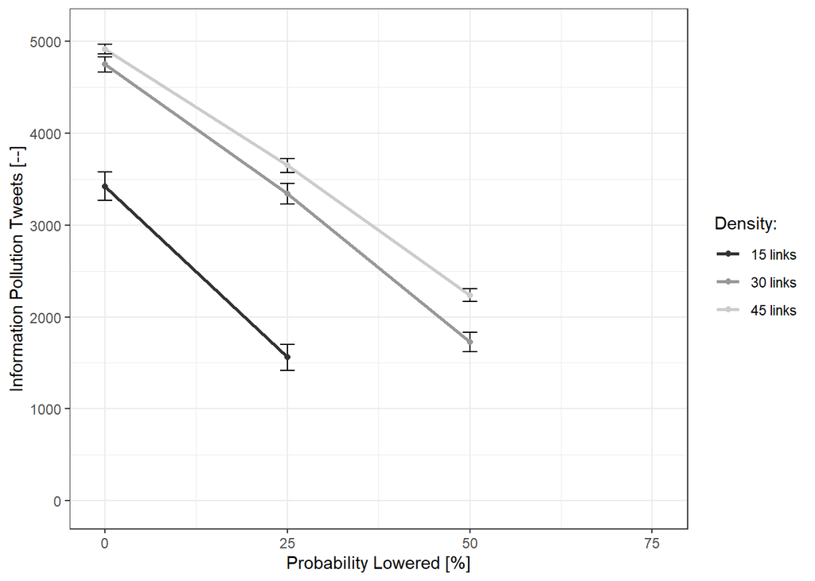

```r
#### creating plots -----------------------------------------------------------------

## "Real-Life" Network Only (365 and All) ---------------
# Preparing Data
data04 <- data02 %>%
  filter(., dens %in% "real") %>%
  filter(., p_warn >= 50) %>%
  mutate(., dat_bas = "all")
data05 <- data03 %>%
  filter(., dens %in% "real") %>%
  mutate(., dat_bas = "365_oly")
data06 <- data04 %>%
  rbind(., data05)

## rendering, showing and saving plot
# rendering
gg01 <- data06 %>%
        ggplot( aes(x = p_warn,
                    group = dat_bas,
                    color = dat_bas) ) +

        geom_line(aes(y = mn_newip ),
                  size = 1.0) +

        geom_errorbar(aes(ymin = mn_newip - sd_newip,
                      ymax = mn_newip + sd_newip),
                      colour = "black",
                      width = 2.0,
                      size = 0.5) +

        geom_point(aes(y = mn_newip),
                   size = 1.5) +

        scale_y_continuous(name ="Information Pollution Tweets [--]",
                           limits = c(-50, 3550)) +

        scale_x_continuous(name = "Probability Lowered [%]",
                           breaks = c(0, 25, 50, 75),
                           limits = c(-1, 76)) +

        scale_color_grey(name = "Runs:",
                         labels = c("365 days", "Less than\n365 days")) +

        theme_bw()

# saving
gg01 %>%
  ggsave(., filename = "./PlotsTables/plt_warn_noip10_lstwt07_real_allobs_01.png",
      units = "cm",
      dpi = "retina",
      height = 8,
      width = 14)


#### "Artificial Network" 365 days Only ---------------------------------------
# rendering
gg02 <- data03 %>%

        filter(., dens %in% c("sim_15", "sim_30", "sim_45")) %>%

        ggplot( aes(x = p_warn,
                    group = dens,
                    color = dens) ) +

        geom_line(aes(y = mn_newip ),
                      size = 1.0) +

        geom_errorbar(aes(ymin = mn_newip - sd_newip,
                          ymax = mn_newip + sd_newip),
                          colour = "black",
                          width = 2.0,
                          size = 0.5) +

        geom_point(aes(y = mn_newip),
                       size = 1.5) +

        scale_y_continuous(name ="Information Pollution Tweets [--]",
                           limits = c(-50, 5100)) +

        scale_x_continuous(name = "Probability Lowered [%]",
                           breaks = c(0, 25, 50, 75),
                           limits = c(-1, 76)) +

        scale_color_grey(name = "Density:",
                         labels = c("15 links", "30 links", "45 links")) +

        theme_bw()

# showing plot
gg02
```

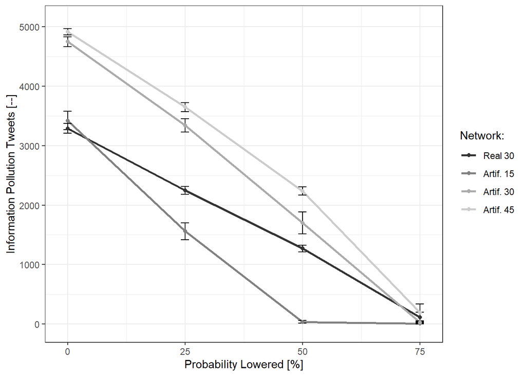

```r
# saving plot
gg02 %>%
  ggsave(., filename = "./PlotsTables/plt_warn_noip10_lstwt07_artif_365_01.png",
      units = "cm",
      dpi = "retina",
      height = 8,
      width = 14)


#### Real and Artificial Networks, All Observations ---------------------------------------
# rendering
gg03 <- data02 %>%

        ggplot( aes(x = p_warn,
                    group = dens,
                    color = dens) ) +

        geom_line(aes(y = mn_newip ),
                      size = 1.0) +

        geom_errorbar(aes(ymin = mn_newip - sd_newip,
                          ymax = mn_newip + sd_newip),
                          colour = "black",
                          width = 1.75,
                          size = 0.5) +

        geom_point(aes(y = mn_newip),
                       size = 1.5) +

        scale_y_continuous(name ="Information Pollution Tweets [--]",
                           limits = c(-50, 5100)) +

        scale_x_continuous(name = "Probability Lowered [%]",
                           breaks = c(0, 25, 50, 75),
                           limits = c(-1, 76)) +

        scale_color_grey(name = "Network:",
                         labels = c("Real 30", "Artif. 15", "Artif. 30", "Artif. 45")) +

        theme_bw()

# showing plot
gg03
```

```r
# saving plot
gg03 %>%
  ggsave(., filename = "./PlotsTables/plt_warn_noip10_lstwt07_all_allobs_01.png",
      units = "cm",
      dpi = "retina",
      height = 8,
      width = 14)

#### Cleanup --------------------------------------------------------------------------------------
## removing auxillary variables
rm(col_lab, n_row)
rm(list = ls(pattern = "data"))
rm(list = ls(pattern = "vct"))
rm(list = ls(pattern = "res"))
rm(list = ls(pattern = "gg"))
```

#### 2. Contermeasure “Account Suspension”

16 x ~20 Runs are performed. Settings for these simulation runs are:

- Real-life Network with 858 members, average node density = 30
  - Run 1: suspending the account for 0 days.
  - Run 2: suspending the account for 2 days (IP-tweet remains invisible).
  - Run 3: suspending the account for 4 days (IP-tweet remains invisible).
  - Run 4: suspending the account for 6 days (IP-tweet remains invisible).
- Simulated Network with 858 members, average node density = 15
  - Run 1: suspending the account for 0 days.
  - Run 2: suspending the account for 2 days (IP-tweet remains invisible).
  - Run 3: suspending the account for 4 days (IP-tweet remains invisible).
  - Run 4: suspending the account for 6 days (IP-tweet remains invisible).
- Simulated Network with 858 members, average node density = 30
  - Run 1: suspending the account for 0 days.
  - Run 2: suspending the account for 2 days (IP-tweet remains invisible).
  - Run 3: suspending the account for 4 days (IP-tweet remains invisible).
  - Run 4: suspending the account for 6 days (IP-tweet remains invisible).
- Simulated Network with 858 members, average node density = 45
  - Run 1: suspending the account for 0 days.
  - Run 2: suspending the account for 2 days (IP-tweet remains invisible).
  - Run 3: suspending the account for 4 days (IP-tweet remains invisible).
  - Run 4: suspending the account for 6 days (IP-tweet remains invisible).

##### 2.1 Data Preparation

```r
## Loading Data
data00 <- read.csv2(file = "./RawData/network_sim_susp_02_03_noip10_lstwt7_365_01.csv") %>%
  `colnames<-`(c("no_sus", "dens", "descr", "val"))


## Brining data in wide format, adding ticks and turtles to same observation
# getting number of rows
n_row <- nrow(data00) # number of rows
# making vector with run-ids (3 values per run)
vct00 <- rep(x = (1:(n_row/3)) , times = 3) %>%
  as.numeric(.) %>%
  sort(.)
# attaching vector to data00 and spread (from long to wide format)
data01 <- data00 %>%
  cbind(., run_id = vct00) %>%
  spread(., key = c("descr"), value = "val") %>%
  dplyr::select(., run_id, no_sus, dens, sum_newip, sum_trltls, ticks)
# saving wide format observations
data01 %>%
   saveRDS(., file = "./RawData/nw_sim_sus_noip10_ls7_356_wide_01.RDS")

## First Plot of Results "Warning"
# with all observations (including those stopping before 365 days)
data02 <- data01 %>%
          group_by(no_sus, dens) %>%
          summarize(mn_newip = mean(sum_newip), sd_newip = sd(sum_newip))

# only observatons that ran to 365 days
data03 <- data01 %>%
          filter(., ticks == 365) %>%
          group_by(no_sus, dens) %>%
          summarize(mn_newip = mean(sum_newip), sd_newip = sd(sum_newip))
```

##### 2.2 Descriptive and OLS

```r
#### calculating Descriptive -------------------------------------------------------------------

## Numbers of ticks for all rounds
# calculating
res_d00 <- data01 %>%
  group_by(., no_sus, dens) %>%
  summarize(mean = mean(ticks))
# showing
res_d00
```

```
## # A tibble: 16 x 3
## # Groups:   no_sus [4]
##    no_sus dens    mean
##     <int> <chr>  <dbl>
##  1      0 real   365
##  2      0 sim_15 365
##  3      0 sim_30 365
##  4      0 sim_45 365
##  5      2 real   365
##  6      2 sim_15 365
##  7      2 sim_30 365
##  8      2 sim_45 365
##  9      4 real   365
## 10      4 sim_15  86.2
## 11      4 sim_30 365
## 12      4 sim_45 365
## 13      6 real   280.
## 14      6 sim_15  19.7
## 15      6 sim_30  76.3
## 16      6 sim_45 365
```

```r
#### performing OLS ----------------------------------------------

## for network density "real" ----------
# all observations
res01a <- data01 %>%
         filter(., dens %in% "real") %>%
         lm(data = ., formula = sum_newip ~ no_sus)
summary(res01a)
```

```
##
## Call:
## lm(formula = sum_newip ~ no_sus, data = .)
##
## Residuals:
##      Min       1Q   Median       3Q      Max
## -1409.15  -200.37    98.85   289.12   562.86
##
## Coefficients:
##             Estimate Std. Error t value Pr(>|t|)
## (Intercept)  3491.12      73.40   47.56   <2e-16 ***
## no_sus       -347.00      19.74  -17.58   <2e-16 ***
## ---
## Signif. codes:  0 '***' 0.001 '**' 0.01 '*' 0.05 '.' 0.1 ' ' 1
##
## Residual standard error: 446.3 on 94 degrees of freedom
## Multiple R-squared:  0.7668, Adjusted R-squared:  0.7644
## F-statistic: 309.1 on 1 and 94 DF,  p-value: < 2.2e-16
```

```r
# observations that ran for 365 days
res01b <- data01 %>%
         filter(., ticks == 365) %>%
         filter(., dens %in% "real") %>%
         lm(data = ., formula = sum_newip ~ no_sus)
summary(res01b)
```

```
##
## Call:
## lm(formula = sum_newip ~ no_sus, data = .)
##
## Residuals:
##     Min      1Q  Median      3Q     Max
## -422.00 -195.74  -23.74  184.77  389.42
##
## Coefficients:
##             Estimate Std. Error t value Pr(>|t|)
## (Intercept)  3417.74      36.63   93.30   <2e-16 ***
## no_sus       -285.29      10.42  -27.37   <2e-16 ***
## ---
## Signif. codes:  0 '***' 0.001 '**' 0.01 '*' 0.05 '.' 0.1 ' ' 1
##
## Residual standard error: 221.2 on 88 degrees of freedom
## Multiple R-squared:  0.8949, Adjusted R-squared:  0.8937
## F-statistic: 749.3 on 1 and 88 DF,  p-value: < 2.2e-16
```

```r
# observations that ran for 365 days & between point 0 & 1
res01b_0_1 <- data01 %>%
         filter(., ticks == 365) %>%
         filter(., dens %in% "real") %>%
         filter(., no_sus == 0 | no_sus == 2) %>%
         lm(data = ., formula = sum_newip ~ no_sus)
summary(res01b_0_1)
```

```
##
## Call:
## lm(formula = sum_newip ~ no_sus, data = .)
##
## Residuals:
##     Min      1Q  Median      3Q     Max
## -153.17  -56.50  -10.59   61.12  174.83
##
## Coefficients:
##             Estimate Std. Error t value Pr(>|t|)
## (Intercept)  3259.00      14.96  217.85  < 2e-16 ***
## no_sus       -120.91      11.03  -10.96 1.14e-14 ***
## ---
## Signif. codes:  0 '***' 0.001 '**' 0.01 '*' 0.05 '.' 0.1 ' ' 1
##
## Residual standard error: 77.73 on 48 degrees of freedom
## Multiple R-squared:  0.7146, Adjusted R-squared:  0.7087
## F-statistic: 120.2 on 1 and 48 DF,  p-value: 1.145e-14
```

```r
# observations that ran for 365 days & between point 1 & 2
res01b_1_2 <- data01 %>%
         filter(., ticks == 365) %>%
         filter(., dens %in% "real") %>%
         filter(., no_sus == 2 | no_sus == 4) %>%
         lm(data = ., formula = sum_newip ~ no_sus)
summary(res01b_1_2)
```

```
##
## Call:
## lm(formula = sum_newip ~ no_sus, data = .)
##
## Residuals:
##      Min       1Q   Median       3Q      Max
## -211.476  -54.651   -8.174   66.751  174.826
##
## Coefficients:
##             Estimate Std. Error t value Pr(>|t|)
## (Intercept)  3517.87      41.17   85.44   <2e-16 ***
## no_sus       -250.35      13.20  -18.96   <2e-16 ***
## ---
## Signif. codes:  0 '***' 0.001 '**' 0.01 '*' 0.05 '.' 0.1 ' ' 1
##
## Residual standard error: 87.48 on 42 degrees of freedom
## Multiple R-squared:  0.8954, Adjusted R-squared:  0.8929
## F-statistic: 359.6 on 1 and 42 DF,  p-value: < 2.2e-16
```

```r
# observations that ran for 365 days & between point 2 & 3
res01b_2_3 <- data01 %>%
         filter(., ticks == 365) %>%
         filter(., dens %in% "real") %>%
         filter(., no_sus == 4 | no_sus == 6) %>%
         lm(data = ., formula = sum_newip ~ no_sus)
summary(res01b_2_3)
```

```
##
## Call:
## lm(formula = sum_newip ~ no_sus, data = .)
##
## Residuals:
##      Min       1Q   Median       3Q      Max
## -211.476  -57.226   -8.054   65.024  163.368
##
## Coefficients:
##             Estimate Std. Error t value Pr(>|t|)
## (Intercept)  4628.17      73.16   63.26   <2e-16 ***
## no_sus       -527.92      14.49  -36.44   <2e-16 ***
## ---
## Signif. codes:  0 '***' 0.001 '**' 0.01 '*' 0.05 '.' 0.1 ' ' 1
##
## Residual standard error: 91.51 on 38 degrees of freedom
## Multiple R-squared:  0.9722, Adjusted R-squared:  0.9714
## F-statistic:  1328 on 1 and 38 DF,  p-value: < 2.2e-16
```

```r
# # observations that ran for 365 days & between point 0 & 2
res01b_0_3 <- data01 %>%
         filter(., ticks == 365) %>%
         filter(., dens %in% "real") %>%
         lm(data = ., formula = sum_newip ~ no_sus)
summary(res01b_0_3)
```

```
##
## Call:
## lm(formula = sum_newip ~ no_sus, data = .)
##
## Residuals:
##     Min      1Q  Median      3Q     Max
## -422.00 -195.74  -23.74  184.77  389.42
##
## Coefficients:
##             Estimate Std. Error t value Pr(>|t|)
## (Intercept)  3417.74      36.63   93.30   <2e-16 ***
## no_sus       -285.29      10.42  -27.37   <2e-16 ***
## ---
## Signif. codes:  0 '***' 0.001 '**' 0.01 '*' 0.05 '.' 0.1 ' ' 1
##
## Residual standard error: 221.2 on 88 degrees of freedom
## Multiple R-squared:  0.8949, Adjusted R-squared:  0.8937
## F-statistic: 749.3 on 1 and 88 DF,  p-value: < 2.2e-16
```

```r
## for network density "sim_15" ----------
# all observations
res02a <- data01 %>%
         filter(., dens %in% "sim_15") %>%
         lm(data = ., formula = sum_newip ~ no_sus)
summary(res02a)
```

```
##
## Call:
## lm(formula = sum_newip ~ no_sus, data = .)
##
## Residuals:
##     Min      1Q  Median      3Q     Max
## -777.59 -180.40   90.92  299.23  744.66
##
## Coefficients:
##             Estimate Std. Error t value Pr(>|t|)
## (Intercept)  3325.08      73.44   45.27   <2e-16 ***
## no_sus       -635.87      21.82  -29.15   <2e-16 ***
## ---
## Signif. codes:  0 '***' 0.001 '**' 0.01 '*' 0.05 '.' 0.1 ' ' 1
##
## Residual standard error: 442.6 on 88 degrees of freedom
## Multiple R-squared:  0.9061, Adjusted R-squared:  0.9051
## F-statistic: 849.6 on 1 and 88 DF,  p-value: < 2.2e-16
```

```r
# observations that ran for 365 days
res02b <- data01 %>%
         filter(., ticks == 365) %>%
         filter(., dens %in% "sim_15") %>%
         lm(data = ., formula = sum_newip ~ no_sus)
summary(res02b)
```

```
##
## Call:
## lm(formula = sum_newip ~ no_sus, data = .)
##
## Residuals:
##     Min      1Q  Median      3Q     Max
## -483.30 -106.23   -2.23   89.70  534.70
##
## Coefficients:
##             Estimate Std. Error t value Pr(>|t|)
## (Intercept)  3368.23      34.64   97.23   <2e-16 ***
## no_sus       -552.47      24.27  -22.77   <2e-16 ***
## ---
## Signif. codes:  0 '***' 0.001 '**' 0.01 '*' 0.05 '.' 0.1 ' ' 1
##
## Residual standard error: 176.6 on 51 degrees of freedom
## Multiple R-squared:  0.9104, Adjusted R-squared:  0.9086
## F-statistic: 518.2 on 1 and 51 DF,  p-value: < 2.2e-16
```

```r
# observations that ran for 365 days & between point 0 & 1
res02b_0_1 <- data01 %>%
         filter(., ticks == 365) %>%
         filter(., dens %in% "sim_15") %>%
         filter(., no_sus == 0 | no_sus == 2) %>%
         lm(data = ., formula = sum_newip ~ no_sus)
summary(res02b_0_1)
```

```
##
## Call:
## lm(formula = sum_newip ~ no_sus, data = .)
##
## Residuals:
##     Min      1Q  Median      3Q     Max
## -483.30 -106.23   -2.23   89.70  534.70
##
## Coefficients:
##             Estimate Std. Error t value Pr(>|t|)
## (Intercept)  3368.23      34.64   97.23   <2e-16 ***
## no_sus       -552.47      24.27  -22.77   <2e-16 ***
## ---
## Signif. codes:  0 '***' 0.001 '**' 0.01 '*' 0.05 '.' 0.1 ' ' 1
##
## Residual standard error: 176.6 on 51 degrees of freedom
## Multiple R-squared:  0.9104, Adjusted R-squared:  0.9086
## F-statistic: 518.2 on 1 and 51 DF,  p-value: < 2.2e-16
```

```r
## for network density "sim_30" ----------
# all observations
res03a <- data01 %>%
         filter(., dens %in% "sim_30") %>%
         lm(data = ., formula = sum_newip ~ no_sus)
summary(res03a)
```

```
##
## Call:
## lm(formula = sum_newip ~ no_sus, data = .)
##
## Residuals:
##    Min     1Q Median     3Q    Max
## -869.8 -785.4 -141.3  675.7 1219.3
##
## Coefficients:
##             Estimate Std. Error t value Pr(>|t|)
## (Intercept)  5438.83     125.18   43.45   <2e-16 ***
## no_sus       -769.04      33.09  -23.24   <2e-16 ***
## ---
## Signif. codes:  0 '***' 0.001 '**' 0.01 '*' 0.05 '.' 0.1 ' ' 1
##
## Residual standard error: 789.7 on 112 degrees of freedom
## Multiple R-squared:  0.8283, Adjusted R-squared:  0.8268
## F-statistic: 540.3 on 1 and 112 DF,  p-value: < 2.2e-16
```

```r
# observations that ran for 365 days
res03b <- data01 %>%
         filter(., ticks == 365) %>%
         filter(., dens %in% "sim_30") %>%
         lm(data = ., formula = sum_newip ~ no_sus)
summary(res03b)
```

```
##
## Call:
## lm(formula = sum_newip ~ no_sus, data = .)
##
## Residuals:
##     Min      1Q  Median      3Q     Max
## -411.65 -174.12  -44.28  214.29  438.04
##
## Coefficients:
##             Estimate Std. Error t value Pr(>|t|)
## (Intercept)  4847.28      36.96  131.14   <2e-16 ***
## no_sus       -333.16      14.42  -23.11   <2e-16 ***
## ---
## Signif. codes:  0 '***' 0.001 '**' 0.01 '*' 0.05 '.' 0.1 ' ' 1
##
## Residual standard error: 211.9 on 82 degrees of freedom
## Multiple R-squared:  0.8668, Adjusted R-squared:  0.8652
## F-statistic: 533.8 on 1 and 82 DF,  p-value: < 2.2e-16
```

```r
# observations that ran for 365 days & between point 0 & 1
res03b_0_1 <- data01 %>%
         filter(., ticks == 365) %>%
         filter(., dens %in% "sim_30") %>%
         filter(., no_sus == 0 | no_sus == 2) %>%
         lm(data = ., formula = sum_newip ~ no_sus)
summary(res03b_0_1)
```

```
##
## Call:
## lm(formula = sum_newip ~ no_sus, data = .)
##
## Residuals:
##    Min     1Q Median     3Q    Max
## -231.6  -65.7   -6.6   69.3  190.4
##
## Coefficients:
##             Estimate Std. Error t value Pr(>|t|)
## (Intercept)  4709.70      17.37  271.07   <2e-16 ***
## no_sus       -140.55      11.97  -11.74   <2e-16 ***
## ---
## Signif. codes:  0 '***' 0.001 '**' 0.01 '*' 0.05 '.' 0.1 ' ' 1
##
## Residual standard error: 90.28 on 55 degrees of freedom
## Multiple R-squared:  0.7147, Adjusted R-squared:  0.7095
## F-statistic: 137.8 on 1 and 55 DF,  p-value: < 2.2e-16
```

```r
# observations that ran for 365 days & between point 1 & 2
res03b_1_2 <- data01 %>%
         filter(., ticks == 365) %>%
         filter(., dens %in% "sim_30") %>%
         filter(., no_sus == 2 | no_sus == 4) %>%
         lm(data = ., formula = sum_newip ~ no_sus)
summary(res03b_1_2)
```

```
##
## Call:
## lm(formula = sum_newip ~ no_sus, data = .)
##
## Residuals:
##    Min     1Q Median     3Q    Max
## -274.1  -59.6   -6.6   82.4  204.9
##
## Coefficients:
##             Estimate Std. Error t value Pr(>|t|)
## (Intercept)  5480.13      43.54  125.87   <2e-16 ***
## no_sus       -525.76      13.99  -37.58   <2e-16 ***
## ---
## Signif. codes:  0 '***' 0.001 '**' 0.01 '*' 0.05 '.' 0.1 ' ' 1
##
## Residual standard error: 105.5 on 55 degrees of freedom
## Multiple R-squared:  0.9625, Adjusted R-squared:  0.9618
## F-statistic:  1412 on 1 and 55 DF,  p-value: < 2.2e-16
```

```r
# # observations that ran for 365 days & between point 0 & 2
res03b_0_2 <- data01 %>%
         filter(., ticks == 365) %>%
         filter(., dens %in% "sim_30") %>%
         filter(., no_sus == 0 | no_sus == 2 | no_sus == 4) %>%
         lm(data = ., formula = sum_newip ~ no_sus)
summary(res03b_0_2)
```

```
##
## Call:
## lm(formula = sum_newip ~ no_sus, data = .)
##
## Residuals:
##     Min      1Q  Median      3Q     Max
## -411.65 -174.12  -44.28  214.29  438.04
##
## Coefficients:
##             Estimate Std. Error t value Pr(>|t|)
## (Intercept)  4847.28      36.96  131.14   <2e-16 ***
## no_sus       -333.16      14.42  -23.11   <2e-16 ***
## ---
## Signif. codes:  0 '***' 0.001 '**' 0.01 '*' 0.05 '.' 0.1 ' ' 1
##
## Residual standard error: 211.9 on 82 degrees of freedom
## Multiple R-squared:  0.8668, Adjusted R-squared:  0.8652
## F-statistic: 533.8 on 1 and 82 DF,  p-value: < 2.2e-16
```

```r
## for network density "sim_45" ----------
# all observations
res04a <- data01 %>%
         filter(., dens %in% "sim_45") %>%
         lm(data = ., formula = sum_newip ~ no_sus)
summary(res04a)
```

```
##
## Call:
## lm(formula = sum_newip ~ no_sus, data = .)
##
## Residuals:
##     Min      1Q  Median      3Q     Max
## -1087.1  -452.2  -318.2   573.7   905.5
##
## Coefficients:
##             Estimate Std. Error t value Pr(>|t|)
## (Intercept)  5300.25     102.93   51.50   <2e-16 ***
## no_sus       -434.19      29.04  -14.95   <2e-16 ***
## ---
## Signif. codes:  0 '***' 0.001 '**' 0.01 '*' 0.05 '.' 0.1 ' ' 1
##
## Residual standard error: 603.9 on 84 degrees of freedom
## Multiple R-squared:  0.7268, Adjusted R-squared:  0.7236
## F-statistic: 223.5 on 1 and 84 DF,  p-value: < 2.2e-16
```

```r
# observations that ran for 365 days
res04b <- data01 %>%
         filter(., ticks == 365) %>%
         filter(., dens %in% "sim_45") %>%
         lm(data = ., formula = sum_newip ~ no_sus)
summary(res04b)
```

```
##
## Call:
## lm(formula = sum_newip ~ no_sus, data = .)
##
## Residuals:
##     Min      1Q  Median      3Q     Max
## -1087.1  -452.2  -318.2   573.7   905.5
##
## Coefficients:
##             Estimate Std. Error t value Pr(>|t|)
## (Intercept)  5300.25     102.93   51.50   <2e-16 ***
## no_sus       -434.19      29.04  -14.95   <2e-16 ***
## ---
## Signif. codes:  0 '***' 0.001 '**' 0.01 '*' 0.05 '.' 0.1 ' ' 1
##
## Residual standard error: 603.9 on 84 degrees of freedom
## Multiple R-squared:  0.7268, Adjusted R-squared:  0.7236
## F-statistic: 223.5 on 1 and 84 DF,  p-value: < 2.2e-16
```

```r
# observations that ran for 365 days & between point 0 & 1
res04b_0_1 <- data01 %>%
         filter(., ticks == 365) %>%
         filter(., dens %in% "sim_45") %>%
         filter(., no_sus == 0 | no_sus == 2) %>%
         lm(data = ., formula = sum_newip ~ no_sus)
summary(res04b_0_1)
```

```
##
## Call:
## lm(formula = sum_newip ~ no_sus, data = .)
##
## Residuals:
##      Min       1Q   Median       3Q      Max
## -165.850  -36.769    9.731   50.731  109.150
##
## Coefficients:
##             Estimate Std. Error t value Pr(>|t|)
## (Intercept) 4899.269     13.175 371.854  < 2e-16 ***
## no_sus       -52.210      9.991  -5.226 4.56e-06 ***
## ---
## Signif. codes:  0 '***' 0.001 '**' 0.01 '*' 0.05 '.' 0.1 ' ' 1
##
## Residual standard error: 67.18 on 44 degrees of freedom
## Multiple R-squared:  0.383,  Adjusted R-squared:  0.3689
## F-statistic: 27.31 on 1 and 44 DF,  p-value: 4.558e-06
```

```r
# observations that ran for 365 days & between point 1 & 2
res04b_1_2 <- data01 %>%
         filter(., ticks == 365) %>%
         filter(., dens %in% "sim_45") %>%
         filter(., no_sus == 2 | no_sus == 4) %>%
         lm(data = ., formula = sum_newip ~ no_sus)
summary(res04b_1_2)
```

```
##
## Call:
## lm(formula = sum_newip ~ no_sus, data = .)
##
## Residuals:
##     Min      1Q  Median      3Q     Max
## -165.85  -69.10    1.65   68.65  143.82
##
## Coefficients:
##             Estimate Std. Error t value Pr(>|t|)
## (Intercept)  5264.52      43.56  120.86   <2e-16 ***
## no_sus       -234.83      13.58  -17.29   <2e-16 ***
## ---
## Signif. codes:  0 '***' 0.001 '**' 0.01 '*' 0.05 '.' 0.1 ' ' 1
##
## Residual standard error: 87.92 on 40 degrees of freedom
## Multiple R-squared:  0.882,  Adjusted R-squared:  0.879
## F-statistic:   299 on 1 and 40 DF,  p-value: < 2.2e-16
```

```r
# observations that ran for 365 days & between point 2 & 3
res04b_2_3 <- data01 %>%
         filter(., ticks == 365) %>%
         filter(., dens %in% "sim_45") %>%
         filter(., no_sus == 4 | no_sus == 6) %>%
         lm(data = ., formula = sum_newip ~ no_sus)
summary(res04b_2_3)
```

```
##
## Call:
## lm(formula = sum_newip ~ no_sus, data = .)
##
## Residuals:
##     Min      1Q  Median      3Q     Max
## -332.00  -77.64   22.00   74.57  260.00
##
## Coefficients:
##             Estimate Std. Error t value Pr(>|t|)
## (Intercept)  9095.55      99.59   91.33   <2e-16 ***
## no_sus      -1192.59      19.92  -59.87   <2e-16 ***
## ---
## Signif. codes:  0 '***' 0.001 '**' 0.01 '*' 0.05 '.' 0.1 ' ' 1
##
## Residual standard error: 125.3 on 38 degrees of freedom
## Multiple R-squared:  0.9895, Adjusted R-squared:  0.9892
## F-statistic:  3585 on 1 and 38 DF,  p-value: < 2.2e-16
```

```r
# observations that ran for 365 days & between point 0 & 2
res04b_0_3 <- data01 %>%
         filter(., ticks == 365) %>%
         filter(., dens %in% "sim_45") %>%
         lm(data = ., formula = sum_newip ~ no_sus)
summary(res04b_0_3)
```

```
##
## Call:
## lm(formula = sum_newip ~ no_sus, data = .)
##
## Residuals:
##     Min      1Q  Median      3Q     Max
## -1087.1  -452.2  -318.2   573.7   905.5
##
## Coefficients:
##             Estimate Std. Error t value Pr(>|t|)
## (Intercept)  5300.25     102.93   51.50   <2e-16 ***
## no_sus       -434.19      29.04  -14.95   <2e-16 ***
## ---
## Signif. codes:  0 '***' 0.001 '**' 0.01 '*' 0.05 '.' 0.1 ' ' 1
##
## Residual standard error: 603.9 on 84 degrees of freedom
## Multiple R-squared:  0.7268, Adjusted R-squared:  0.7236
## F-statistic: 223.5 on 1 and 84 DF,  p-value: < 2.2e-16
```

```r
#### saving results
## "real", observations that ran 365 days
# defining column labels
col_lab = c("0 to 2 days", "2 to 4 days",
            "4 to 6 days", "0 to 6 days")
# rendering and saving regression table
stargazer(res01b_0_1, res01b_1_2,
          res01b_2_3, res01b_0_3,
         column.labels = col_lab,
         title = "Countermeasure Account Suspension",
         style = "apsr",
         digits = 2,
         type = "html",
         out = "./PlotsTables/ols_susp_noip10_lstwt07_365_real_02.html")
```

```
##
## <table style="text-align:center"><caption><strong>Countermeasure Account Suspension</strong></caption>
## <tr><td colspan="5" style="border-bottom: 1px solid black"></td></tr><tr><td style="text-align:left"></td><td colspan="4">sum_newip</td></tr>
## <tr><td style="text-align:left"></td><td>0 to 2 days</td><td>2 to 4 days</td><td>4 to 6 days</td><td>0 to 6 days</td></tr>
## <tr><td style="text-align:left"></td><td>(1)</td><td>(2)</td><td>(3)</td><td>(4)</td></tr>
## <tr><td colspan="5" style="border-bottom: 1px solid black"></td></tr><tr><td style="text-align:left">no_sus</td><td>-120.91<sup>***</sup></td><td>-250.35<sup>***</sup></td><td>-527.92<sup>***</sup></td><td>-285.29<sup>***</sup></td></tr>
## <tr><td style="text-align:left"></td><td>(11.03)</td><td>(13.20)</td><td>(14.49)</td><td>(10.42)</td></tr>
## <tr><td style="text-align:left">Constant</td><td>3,259.00<sup>***</sup></td><td>3,517.87<sup>***</sup></td><td>4,628.17<sup>***</sup></td><td>3,417.74<sup>***</sup></td></tr>
## <tr><td style="text-align:left"></td><td>(14.96)</td><td>(41.17)</td><td>(73.16)</td><td>(36.63)</td></tr>
## <tr><td style="text-align:left">N</td><td>50</td><td>44</td><td>40</td><td>90</td></tr>
## <tr><td style="text-align:left">R<sup>2</sup></td><td>0.71</td><td>0.90</td><td>0.97</td><td>0.89</td></tr>
## <tr><td style="text-align:left">Adjusted R<sup>2</sup></td><td>0.71</td><td>0.89</td><td>0.97</td><td>0.89</td></tr>
## <tr><td style="text-align:left">Residual Std. Error</td><td>77.73 (df = 48)</td><td>87.48 (df = 42)</td><td>91.51 (df = 38)</td><td>221.20 (df = 88)</td></tr>
## <tr><td style="text-align:left">F Statistic</td><td>120.20<sup>***</sup> (df = 1; 48)</td><td>359.62<sup>***</sup> (df = 1; 42)</td><td>1,327.85<sup>***</sup> (df = 1; 38)</td><td>749.34<sup>***</sup> (df = 1; 88)</td></tr>
## <tr><td colspan="5" style="border-bottom: 1px solid black"></td></tr><tr><td colspan="5" style="text-align:left"><sup>*</sup>p < .1; <sup>**</sup>p < .05; <sup>***</sup>p < .01</td></tr>
## </table>
```

```r
## All models, observations that ran 365 days
# defining column labels
col_lab = c("Sim 15: 0-2",
            "Sim 30: 0-2", "Sim 30: 2-4", "Sim 30: 0-4",
            "Sim 45: 0-2", "Sim 45: 2-4", "Sim 45: 4-6", "Sim 45: 0-6",
            "Real: 0-2", "Real: 2-4", "Real: 4-6", "Real: 0-6")
# rendering and saving regression table
stargazer(res02b_0_1,
          res03b_0_1, res03b_1_2, res03b_0_2,
          res04b_0_1, res04b_1_2, res04b_2_3, res04b_0_3,
          res01b_0_1, res01b_1_2, res01b_2_3, res01b_0_3,
          column.labels = col_lab,
          title = "Countermeasure Account Suspension",
          style = "apsr",
          digits = 2,
          type = "html",
          out = "./PlotsTables/ols_susp_noip10_lstwt07_365_sim_02.html")
```

```
##
## <table style="text-align:center"><caption><strong>Countermeasure Account Suspension</strong></caption>
## <tr><td colspan="13" style="border-bottom: 1px solid black"></td></tr><tr><td style="text-align:left"></td><td colspan="12">sum_newip</td></tr>
## <tr><td style="text-align:left"></td><td>Sim 15: 0-2</td><td>Sim 30: 0-2</td><td>Sim 30: 2-4</td><td>Sim 30: 0-4</td><td>Sim 45: 0-2</td><td>Sim 45: 2-4</td><td>Sim 45: 4-6</td><td>Sim 45: 0-6</td><td>Real: 0-2</td><td>Real: 2-4</td><td>Real: 4-6</td><td>Real: 0-6</td></tr>
## <tr><td style="text-align:left"></td><td>(1)</td><td>(2)</td><td>(3)</td><td>(4)</td><td>(5)</td><td>(6)</td><td>(7)</td><td>(8)</td><td>(9)</td><td>(10)</td><td>(11)</td><td>(12)</td></tr>
## <tr><td colspan="13" style="border-bottom: 1px solid black"></td></tr><tr><td style="text-align:left">no_sus</td><td>-552.47<sup>***</sup></td><td>-140.55<sup>***</sup></td><td>-525.76<sup>***</sup></td><td>-333.16<sup>***</sup></td><td>-52.21<sup>***</sup></td><td>-234.83<sup>***</sup></td><td>-…
## <tr><td style="text-align:left"></td><td>(24.27)</td><td>(11.97)</td><td>(13.99)</td><td>(14.42)</td><td>(9.99)</td><td>(13.58)</td><td>(19.92)</td><td>(29.04)</td><td>(11.03)</td><td>(13.20)</td><td>(14.49)</td><td>(10.42)</td></tr>
## <tr><td style="text-align:left">Constant</td><td>3,368.23<sup>***</sup></td><td>4,709.70<sup>***</sup></td><td>5,480.13<sup>***</sup></td><td>4,847.28<sup>***</sup></td><td>4,899.27<sup>***</sup></td><td>5,264.52<sup>***</sup></td><td>9,095.55<sup>***</sup></td><td>5,300.25<sup>***</sup></td><td>…
## <tr><td style="text-align:left"></td><td>(34.64)</td><td>(17.37)</td><td>(43.54)</td><td>(36.96)</td><td>(13.18)</td><td>(43.56)</td><td>(99.59)</td><td>(102.93)</td><td>(14.96)</td><td>(41.17)</td><td>(73.16)</td><td>(36.63)</td></tr>
## <tr><td style="text-align:left">N</td><td>53</td><td>57</td><td>57</td><td>84</td><td>46</td><td>42</td><td>40</td><td>86</td><td>50</td><td>44</td><td>40</td><td>90</td></tr>
## <tr><td style="text-align:left">R<sup>2</sup></td><td>0.91</td><td>0.71</td><td>0.96</td><td>0.87</td><td>0.38</td><td>0.88</td><td>0.99</td><td>0.73</td><td>0.71</td><td>0.90</td><td>0.97</td><td>0.89</td></tr>
## <tr><td style="text-align:left">Adjusted R<sup>2</sup></td><td>0.91</td><td>0.71</td><td>0.96</td><td>0.87</td><td>0.37</td><td>0.88</td><td>0.99</td><td>0.72</td><td>0.71</td><td>0.89</td><td>0.97</td><td>0.89</td></tr>
## <tr><td style="text-align:left">Residual Std. Error</td><td>176.65 (df = 51)</td><td>90.28 (df = 55)</td><td>105.48 (df = 55)</td><td>211.92 (df = 82)</td><td>67.18 (df = 44)</td><td>87.92 (df = 40)</td><td>125.34 (df = 38)</td><td>603.94 (df = 84)</td><td>77.73 (df = 48)</td><td>87.48 (df = 42)<…
## <tr><td style="text-align:left">F Statistic</td><td>518.23<sup>***</sup> (df = 1; 51)</td><td>137.78<sup>***</sup> (df = 1; 55)</td><td>1,412.23<sup>***</sup> (df = 1; 55)</td><td>533.83<sup>***</sup> (df = 1; 82)</td><td>27.31<sup>***</sup> (df = 1; 44)</td><td>298.95<sup>***</sup> (df = 1; 40)<…
## <tr><td colspan="13" style="border-bottom: 1px solid black"></td></tr><tr><td colspan="13" style="text-align:left"><sup>*</sup>p < .1; <sup>**</sup>p < .05; <sup>***</sup>p < .01</td></tr>
## </table>
```

```r
# getting Summaries (various)
res05 <- data01 %>%
         filter(., dens %in% "sim_30") %>%
         filter(., no_sus == 4) %>%
         dplyr::select(., ticks) %>%
         summary(.)
res05
```

```
##      ticks
##  Min.   :365
##  1st Qu.:365
##  Median :365
##  Mean   :365
##  3rd Qu.:365
##  Max.   :365
```

```r
# getting Survivors (various)
res06 <- data01 %>%
         filter(., dens %in% "sim_45") %>%
         filter(., no_sus == 6) %>%
         arrange(desc(ticks))
res06
```

```
##    run_id no_sus   dens sum_newip sum_trltls ticks
## 1     255      6 sim_45      1985        858   365
## 2     256      6 sim_45      1976        858   365
## 3     257      6 sim_45      2200        858   365
## 4     258      6 sim_45      2074        858   365
## 5     259      6 sim_45      1849        858   365
## 6     260      6 sim_45      2008        858   365
## 7     261      6 sim_45      1907        858   365
## 8     262      6 sim_45      1819        858   365
## 9     263      6 sim_45      1616        858   365
## 10    264      6 sim_45      1608        858   365
## 11    265      6 sim_45      1961        858   365
## 12    266      6 sim_45      2055        858   365
## 13    267      6 sim_45      2132        858   365
## 14    268      6 sim_45      1963        858   365
## 15    269      6 sim_45      2004        858   365
## 16    270      6 sim_45      2007        858   365
## 17    271      6 sim_45      1913        858   365
## 18    272      6 sim_45      1843        858   365
```

##### 2.3 Plots

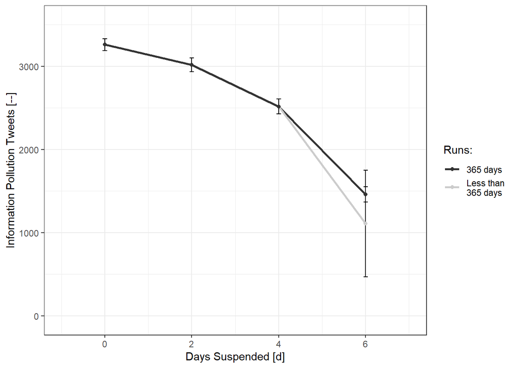

```r
#### "Real-Life" Network Only ---------------------------------------
# Preparing Data
data04 <- data02 %>%
  filter(., dens %in% "real") %>%
  filter(., no_sus >= 4) %>%
  mutate(., dat_bas = "all")
data05 <- data03 %>%
  filter(., dens %in% "real") %>%
  mutate(., dat_bas = "365_oly")
data06 <- data04 %>%
  rbind(., data05)

# rendering, showing and saving plot
gg01 <- data06 %>%
        ggplot( aes(x = no_sus,
                    group = dat_bas,
                    color = dat_bas) ) +

        geom_line(aes(y = mn_newip ),
                      size = 1.0) +

        geom_errorbar(aes(ymin = mn_newip - sd_newip,
                          ymax = mn_newip + sd_newip),
                          colour = "black",
                          width = 0.1,
                          size = 0.5) +

        geom_point(aes(y = mn_newip),
                       size = 1.5) +

        scale_y_continuous(name ="Information Pollution Tweets [--]",
                           limits = c(-50, 3550)) +

        scale_x_continuous(name = "Days Suspended [d]",
                           breaks = c(0, 2, 4, 6),
                           limits = c(-1, 7)) +

        scale_color_grey(name = "Runs:",
                         labels = c("365 days", "Less than\n365 days")) +

        theme_bw()

# showing plot
gg01
```

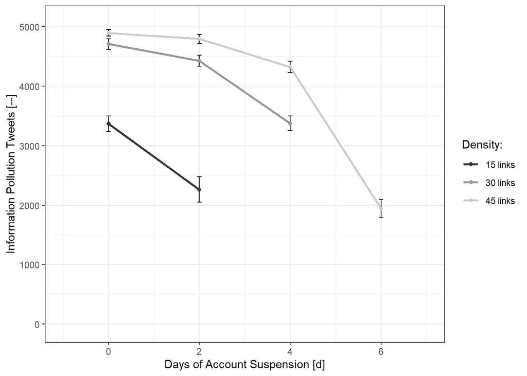

```r
# saving plot
gg01 %>%
  ggsave(., filename = "./PlotsTables/plt_susp_noip10_lstwt07_real_allobs_01.png",
      units = "cm",
      dpi = "retina",
      height = 8,
      width = 14)



#### "Artificial Network" 365 days Only ---------------------------------------
# rendering
gg02 <- data03 %>%

        filter(., dens %in% c("sim_15", "sim_30", "sim_45")) %>%

        ggplot( aes(x = no_sus,
                    group = dens,
                    color = dens) ) +

        geom_line(aes(y = mn_newip ),
                      size = 1.0) +

        geom_errorbar(aes(ymin = mn_newip - sd_newip,
                          ymax = mn_newip + sd_newip),
                          colour = "black",
                          width = 0.1,
                          size = 0.5) +

        geom_point(aes(y = mn_newip),
                       size = 1.5) +

        scale_y_continuous(name ="Information Pollution Tweets [--]",
                           limits = c(-50, 5100)) +

        scale_x_continuous(name = "Days of Account Suspension [d]",
                           breaks = c(0, 2, 4, 6),
                           limits = c(-1, 7)) +

        scale_color_grey(name = "Density:",
                         labels = c("15 links", "30 links", "45 links")) +

        theme_bw()

# showing plot
gg02
```

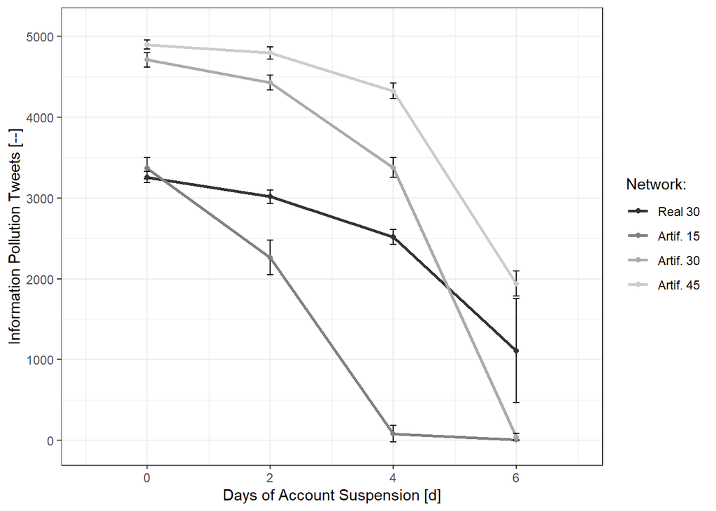

```r
# saving plot
gg02 %>%
  ggsave(., filename = "./PlotsTables/plt_susp_noip10_lstwt07_artif_365_01.png",
      units = "cm",
      dpi = "retina",
      height = 8,
      width = 14)


#### Real and Artificial Networks, All Observations ---------------------------------------
# rendering
gg03 <- data02 %>%

        ggplot( aes(x = no_sus,
                    group = dens,
                    color = dens) ) +

        geom_line(aes(y = mn_newip ),
                      size = 1.0) +

        geom_errorbar(aes(ymin = mn_newip - sd_newip,
                          ymax = mn_newip + sd_newip),
                          colour = "black",
                          width = 0.1,
                          size = 0.5) +

        geom_point(aes(y = mn_newip),
                       size = 1.5) +

        scale_y_continuous(name ="Information Pollution Tweets [--]",
                           limits = c(-50, 5100)) +

        scale_x_continuous(name = "Days of Account Suspension [d]",
                           breaks = c(0, 2, 4, 6),
                           limits = c(-1, 7)) +

        scale_color_grey(name = "Network:",
                         labels = c("Real 30", "Artif. 15", "Artif. 30", "Artif. 45")) +

        theme_bw()

# showing plot
gg03
```

```r
# saving plot
gg03 %>%
  ggsave(., filename = "./PlotsTables/plt_susp_noip10_lstwt07_all_allobs_01.png",
      units = "cm",
      dpi = "retina",
      height = 8,
      width = 14)


## removing auxillary variables
rm(col_lab, n_row)
rm(list= ls(pattern= "data"))
rm(list= ls(pattern= "vct"))
rm(list= ls(pattern= "res"))
rm(list= ls(pattern= "gg"))
```

#### 3. Contermeasure “Account Ban”

16 x ~20 Runs are performed. Settings for these simulation runs are:

- Real-life Network with 858 members, average node density = 30
  - Run 1: banning 0 accounts.
  - Run 2: banning 91 accounts (one every 4 days).
  - Run 3: banning 183 accounts (one every 2 days).
  - Run 4: banning 273 accounts (one every 36 hours).
- Simulated Network with 858 members, average node density = 15
  - Run 1: banning 0 accounts.
  - Run 2: banning 91 accounts (one every 4 days).
  - Run 3: banning 183 accounts (one every 2 days).
  - Run 4: banning 273 accounts (one every 36 hours).
- Simulated Network with 858 members, average node density = 30
  - Run 1: banning 0 accounts.
  - Run 2: banning 91 accounts (one every 4 days).
  - Run 3: banning 183 accounts (one every 2 days).
  - Run 4: banning 273 accounts (one every 36 hours).
- Simulated Network with 858 members, average node density = 45
  - Run 1: banning 0 accounts.
  - Run 2: banning 91 accounts (one every 4 days).
  - Run 3: banning 183 accounts (one every 2 days).
  - Run 4: banning 273 accounts (one every 36 hours).

##### 3.1 Data Preparation

```r
#### Loading Data
data00 <- read.csv2(file = "./RawData/network_sim_ban_02_03_noip10_lstwt7_365_02.csv") %>%
   dplyr::select(., "ï..strg", dens, dscr, val) %>%
  `colnames<-`(c("no_del", "dens", "descr", "val"))


## Brining data in wide format, adding ticks and turtles to same observation
# getting number of rows
n_row <- nrow(data00) # number of rows
# making vector with run-ids (3 values per run)
vct00 <- rep(x = (1:(n_row/3)) , times = 3) %>%
  as.numeric(.) %>%
  sort(.)
# attaching vector to data00 and spread (from long to wide format)
data01 <- data00 %>%
  cbind(., run_id = vct00) %>%
  spread(., key = c("descr"), value = "val") %>%
  dplyr::select(., run_id, no_del, dens, sum_newip, sum_trltls, ticks)
# saving wide format observations
data01 %>%
   saveRDS(., file = "./RawData/nw_sim_ban_noip10_ls7_356_wide_01.RDS")

## First Plot of Results "Warning"
# with all observations (including those stopping before 365 days)
data02 <- data01 %>%
          group_by(no_del, dens) %>%
          summarize(mn_newip = mean(sum_newip), sd_newip = sd(sum_newip))
# only observatons that ran to 365 days
data03 <- data01 %>%
          filter(., ticks == 365) %>%
          group_by(no_del, dens) %>%
          summarize(mn_newip = mean(sum_newip), sd_newip = sd(sum_newip))
```

##### 3.2 Descriptive and OLS

```r
## Numbers of ticks for all rounds
# calculating
res_d00 <- data01 %>%
  group_by(., no_del, dens) %>%
  summarize(mean = mean(ticks))
# showing
res_d00
```

```
## # A tibble: 16 x 3
## # Groups:   no_del [4]
##    no_del dens    mean
##     <int> <chr>  <dbl>
##  1      0 real    365
##  2      0 sim_15  365
##  3      0 sim_30  365
##  4      0 sim_45  365
##  5     91 real    365
##  6     91 sim_15  365
##  7     91 sim_30  365
##  8     91 sim_45  365
##  9    183 real    365
## 10    183 sim_15  299.
## 11    183 sim_30  365
## 12    183 sim_45  365
## 13    273 real    347.
## 14    273 sim_15  191.
## 15    273 sim_30  365
## 16    273 sim_45  365
```

```r
#### performing OLS ----------------------------------------------

## for network density "real" ----------
# all observations
res01a <- data01 %>%
         filter(., dens %in% "real") %>%
         lm(data = ., formula = sum_newip ~ no_del)
summary(res01a)
```

```
##
## Call:
## lm(formula = sum_newip ~ no_del, data = .)
##
## Residuals:
##      Min       1Q   Median       3Q      Max
## -290.238  -62.866    1.134   67.384  179.762
##
## Coefficients:
##               Estimate Std. Error t value Pr(>|t|)
## (Intercept) 3283.49385   14.43105  227.53   <2e-16 ***
## no_del        -5.20240    0.08979  -57.94   <2e-16 ***
## ---
## Signif. codes:  0 '***' 0.001 '**' 0.01 '*' 0.05 '.' 0.1 ' ' 1
##
## Residual standard error: 93.57 on 94 degrees of freedom
## Multiple R-squared:  0.9728, Adjusted R-squared:  0.9725
## F-statistic:  3357 on 1 and 94 DF,  p-value: < 2.2e-16
```

```r
# observations that ran for 365 days
res01b <- data01 %>%
         filter(., ticks == 365) %>%
         filter(., dens %in% "real") %>%
         lm(data = ., formula = sum_newip ~ no_del)
summary(res01b)
```

```
##
## Call:
## lm(formula = sum_newip ~ no_del, data = .)
##
## Residuals:
##      Min       1Q   Median       3Q      Max
## -174.967  -54.967   -6.183   67.033  149.276
##
## Coefficients:
##               Estimate Std. Error t value Pr(>|t|)
## (Intercept) 3273.49391   12.43247  263.30   <2e-16 ***
## no_del        -4.98649    0.09587  -52.01   <2e-16 ***
## ---
## Signif. codes:  0 '***' 0.001 '**' 0.01 '*' 0.05 '.' 0.1 ' ' 1
##
## Residual standard error: 78.63 on 79 degrees of freedom
## Multiple R-squared:  0.9716, Adjusted R-squared:  0.9713
## F-statistic:  2705 on 1 and 79 DF,  p-value: < 2.2e-16
```

```r
# observations that ran for 365 days & between point 0 & 1
res01b_0_1 <- data01 %>%
         filter(., ticks == 365) %>%
         filter(., dens %in% "real") %>%
         filter(., no_del == 0 | no_del == 91) %>%
         lm(data = ., formula = sum_newip ~ no_del)
summary(res01b_0_1)
```

```
##
## Call:
## lm(formula = sum_newip ~ no_del, data = .)
##
## Residuals:
##      Min       1Q   Median       3Q      Max
## -142.433  -61.458   -8.533   58.567  135.467
##
## Coefficients:
##              Estimate Std. Error t value Pr(>|t|)
## (Intercept) 3259.5333    12.9816  251.09   <2e-16 ***
## no_del        -4.5945     0.2017  -22.77   <2e-16 ***
## ---
## Signif. codes:  0 '***' 0.001 '**' 0.01 '*' 0.05 '.' 0.1 ' ' 1
##
## Residual standard error: 71.1 on 58 degrees of freedom
## Multiple R-squared:  0.8994, Adjusted R-squared:  0.8977
## F-statistic: 518.6 on 1 and 58 DF,  p-value: < 2.2e-16
```

```r
# observations that ran for 365 days & between point 1 & 2
res01b_1_2 <- data01 %>%
         filter(., ticks == 365) %>%
         filter(., dens %in% "real") %>%
         filter(., no_del == 91 | no_del == 183) %>%
         lm(data = ., formula = sum_newip ~ no_del)
summary(res01b_1_2)
```

```
##
## Call:
## lm(formula = sum_newip ~ no_del, data = .)
##
## Residuals:
##      Min       1Q   Median       3Q      Max
## -170.727  -67.433   -2.433   77.567  127.567
##
## Coefficients:
##              Estimate Std. Error t value Pr(>|t|)
## (Intercept) 3320.8708    41.2855   80.44   <2e-16 ***
## no_del        -5.2685     0.3366  -15.65   <2e-16 ***
## ---
## Signif. codes:  0 '***' 0.001 '**' 0.01 '*' 0.05 '.' 0.1 ' ' 1
##
## Residual standard error: 87.86 on 39 degrees of freedom
## Multiple R-squared:  0.8627, Adjusted R-squared:  0.8592
## F-statistic:   245 on 1 and 39 DF,  p-value: < 2.2e-16
```

```r
# observations that ran for 365 days & between point 2 & 3
res01b_2_3 <- data01 %>%
         filter(., ticks == 365) %>%
         filter(., dens %in% "real") %>%
         filter(., no_del == 183 | no_del == 273) %>%
         lm(data = ., formula = sum_newip ~ no_del)
summary(res01b_2_3)
```

```
##
## Call:
## lm(formula = sum_newip ~ no_del, data = .)
##
## Residuals:
##     Min      1Q  Median      3Q     Max
## -170.73  -40.73   12.40   71.27  132.40
##
## Coefficients:
##              Estimate Std. Error t value Pr(>|t|)
## (Intercept) 3298.4194   106.2377   31.05  < 2e-16 ***
## no_del        -5.1459     0.4613  -11.15 8.81e-10 ***
## ---
## Signif. codes:  0 '***' 0.001 '**' 0.01 '*' 0.05 '.' 0.1 ' ' 1
##
## Residual standard error: 95.03 on 19 degrees of freedom
## Multiple R-squared:  0.8675, Adjusted R-squared:  0.8606
## F-statistic: 124.4 on 1 and 19 DF,  p-value: 8.809e-10
```

```r
# # observations that ran for 365 days & between point 0 & 2
res01b_0_3 <- data01 %>%
         filter(., ticks == 365) %>%
         filter(., dens %in% "real") %>%
         lm(data = ., formula = sum_newip ~ no_del)
summary(res01b_0_3)
```

```
##
## Call:
## lm(formula = sum_newip ~ no_del, data = .)
##
## Residuals:
##      Min       1Q   Median       3Q      Max
## -174.967  -54.967   -6.183   67.033  149.276
##
## Coefficients:
##               Estimate Std. Error t value Pr(>|t|)
## (Intercept) 3273.49391   12.43247  263.30   <2e-16 ***
## no_del        -4.98649    0.09587  -52.01   <2e-16 ***
## ---
## Signif. codes:  0 '***' 0.001 '**' 0.01 '*' 0.05 '.' 0.1 ' ' 1
##
## Residual standard error: 78.63 on 79 degrees of freedom
## Multiple R-squared:  0.9716, Adjusted R-squared:  0.9713
## F-statistic:  2705 on 1 and 79 DF,  p-value: < 2.2e-16
```

```r
## for network density "sim_15" ----------
# all observations
res02a <- data01 %>%
         filter(., dens %in% "sim_15") %>%
         lm(data = ., formula = sum_newip ~ no_del)
summary(res02a)
```

```
##
## Call:
## lm(formula = sum_newip ~ no_del, data = .)
##
## Residuals:
##      Min       1Q   Median       3Q      Max
## -1803.69   -99.84    42.34   161.88   506.45
##
## Coefficients:
##              Estimate Std. Error t value Pr(>|t|)
## (Intercept) 3409.6627    45.3512   75.18   <2e-16 ***
## no_del        -8.7594     0.2727  -32.12   <2e-16 ***
## ---
## Signif. codes:  0 '***' 0.001 '**' 0.01 '*' 0.05 '.' 0.1 ' ' 1
##
## Residual standard error: 295.7 on 117 degrees of freedom
## Multiple R-squared:  0.8982, Adjusted R-squared:  0.8973
## F-statistic:  1032 on 1 and 117 DF,  p-value: < 2.2e-16
```

```r
# observations that ran for 365 days
res02b <- data01 %>%
         filter(., ticks == 365) %>%
         filter(., dens %in% "sim_15") %>%
         lm(data = ., formula = sum_newip ~ no_del)
summary(res02b)
```

```
##
## Call:
## lm(formula = sum_newip ~ no_del, data = .)
##
## Residuals:
##     Min      1Q  Median      3Q     Max
## -360.93  -90.34    1.32   98.07  404.32
##
## Coefficients:
##              Estimate Std. Error t value Pr(>|t|)
## (Intercept) 3359.9311    25.8522  129.97   <2e-16 ***
## no_del        -7.0907     0.3232  -21.94   <2e-16 ***
## ---
## Signif. codes:  0 '***' 0.001 '**' 0.01 '*' 0.05 '.' 0.1 ' ' 1
##
## Residual standard error: 148.6 on 63 degrees of freedom
## Multiple R-squared:  0.8843, Adjusted R-squared:  0.8824
## F-statistic: 481.3 on 1 and 63 DF,  p-value: < 2.2e-16
```

```r
# observations that ran for 365 days & between point 0 & 1
res02b_0_1 <- data01 %>%
         filter(., ticks == 365) %>%
         filter(., dens %in% "sim_15") %>%
         filter(., no_del == 0 | no_del == 91) %>%
         lm(data = ., formula = sum_newip ~ no_del)
summary(res02b_0_1)
```

```
##
## Call:
## lm(formula = sum_newip ~ no_del, data = .)
##
## Residuals:
##    Min     1Q Median     3Q    Max
## -357.1  -93.0   -0.7  106.2  396.7
##
## Coefficients:
##              Estimate Std. Error t value Pr(>|t|)
## (Intercept) 3356.1000    27.8327   120.6   <2e-16 ***
## no_del        -6.9648     0.4325   -16.1   <2e-16 ***
## ---
## Signif. codes:  0 '***' 0.001 '**' 0.01 '*' 0.05 '.' 0.1 ' ' 1
##
## Residual standard error: 152.4 on 58 degrees of freedom
## Multiple R-squared:  0.8172, Adjusted R-squared:  0.814
## F-statistic: 259.3 on 1 and 58 DF,  p-value: < 2.2e-16
```

```r
# observations that ran for 365 days & between point 1 & 2
res02b_1_2 <- data01 %>%
         filter(., ticks == 365) %>%
         filter(., dens %in% "sim_15") %>%
         filter(., no_del == 91 | no_del == 183) %>%
         lm(data = ., formula = sum_newip ~ no_del)
summary(res02b_1_2)
```

```
##
## Call:
## lm(formula = sum_newip ~ no_del, data = .)
##
## Residuals:
##    Min     1Q Median     3Q    Max
## -348.3 -101.8   -4.3   94.9  396.7
##
## Coefficients:
##             Estimate Std. Error t value Pr(>|t|)
## (Intercept) 3397.579     91.888  36.975  < 2e-16 ***
## no_del        -7.421      0.843  -8.803 3.56e-10 ***
## ---
## Signif. codes:  0 '***' 0.001 '**' 0.01 '*' 0.05 '.' 0.1 ' ' 1
##
## Residual standard error: 160.6 on 33 degrees of freedom
## Multiple R-squared:  0.7013, Adjusted R-squared:  0.6923
## F-statistic: 77.49 on 1 and 33 DF,  p-value: 3.562e-10
```

```r
# observations that ran for 365 days & between point 0 & 2
res02b_0_2 <- data01 %>%
         filter(., ticks == 365) %>%
         filter(., dens %in% "sim_15") %>%
         lm(data = ., formula = sum_newip ~ no_del)
summary(res02b_0_2)
```

```
##
## Call:
## lm(formula = sum_newip ~ no_del, data = .)
##
## Residuals:
##     Min      1Q  Median      3Q     Max
## -360.93  -90.34    1.32   98.07  404.32
##
## Coefficients:
##              Estimate Std. Error t value Pr(>|t|)
## (Intercept) 3359.9311    25.8522  129.97   <2e-16 ***
## no_del        -7.0907     0.3232  -21.94   <2e-16 ***
## ---
## Signif. codes:  0 '***' 0.001 '**' 0.01 '*' 0.05 '.' 0.1 ' ' 1
##
## Residual standard error: 148.6 on 63 degrees of freedom
## Multiple R-squared:  0.8843, Adjusted R-squared:  0.8824
## F-statistic: 481.3 on 1 and 63 DF,  p-value: < 2.2e-16
```

```r
## for network density "sim_30" ----------
# all observations
res03a <- data01 %>%
         filter(., dens %in% "sim_30") %>%
         lm(data = ., formula = sum_newip ~ no_del)
summary(res03a)
```

```
##
## Call:
## lm(formula = sum_newip ~ no_del, data = .)
##
## Residuals:
##      Min       1Q   Median       3Q      Max
## -209.789  -64.553    0.211   63.447  211.806
##
## Coefficients:
##               Estimate Std. Error t value Pr(>|t|)
## (Intercept) 4762.55274   13.49834  352.82   <2e-16 ***
## no_del        -5.18229    0.07672  -67.55   <2e-16 ***
## ---
## Signif. codes:  0 '***' 0.001 '**' 0.01 '*' 0.05 '.' 0.1 ' ' 1
##
## Residual standard error: 84.63 on 115 degrees of freedom
## Multiple R-squared:  0.9754, Adjusted R-squared:  0.9752
## F-statistic:  4562 on 1 and 115 DF,  p-value: < 2.2e-16
```

```r
# observations that ran for 365 days
res03b <- data01 %>%
         filter(., ticks == 365) %>%
         filter(., dens %in% "sim_30") %>%
         lm(data = ., formula = sum_newip ~ no_del)
summary(res03b)
```

```
##
## Call:
## lm(formula = sum_newip ~ no_del, data = .)
##
## Residuals:
##      Min       1Q   Median       3Q      Max
## -209.789  -64.553    0.211   63.447  211.806
##
## Coefficients:
##               Estimate Std. Error t value Pr(>|t|)
## (Intercept) 4762.55274   13.49834  352.82   <2e-16 ***
## no_del        -5.18229    0.07672  -67.55   <2e-16 ***
## ---
## Signif. codes:  0 '***' 0.001 '**' 0.01 '*' 0.05 '.' 0.1 ' ' 1
##
## Residual standard error: 84.63 on 115 degrees of freedom
## Multiple R-squared:  0.9754, Adjusted R-squared:  0.9752
## F-statistic:  4562 on 1 and 115 DF,  p-value: < 2.2e-16
```

```r
# observations that ran for 365 days & between point 0 & 1
res03b_0_1 <- data01 %>%
         filter(., ticks == 365) %>%
         filter(., dens %in% "sim_30") %>%
         filter(., no_del == 0 | no_del == 91) %>%
         lm(data = ., formula = sum_newip ~ no_del)
summary(res03b_0_1)
```

```
##
## Call:
## lm(formula = sum_newip ~ no_del, data = .)
##
## Residuals:
##      Min       1Q   Median       3Q      Max
## -151.704  -55.929   -3.704   57.434  151.296
##
## Coefficients:
##              Estimate Std. Error t value Pr(>|t|)
## (Intercept) 4744.7037    14.5356  326.42   <2e-16 ***
## no_del        -5.0799     0.2239  -22.69   <2e-16 ***
## ---
## Signif. codes:  0 '***' 0.001 '**' 0.01 '*' 0.05 '.' 0.1 ' ' 1
##
## Residual standard error: 75.53 on 53 degrees of freedom
## Multiple R-squared:  0.9067, Adjusted R-squared:  0.9049
## F-statistic: 514.9 on 1 and 53 DF,  p-value: < 2.2e-16
```

```r
# observations that ran for 365 days & between point 1 & 2
res03b_1_2 <- data01 %>%
         filter(., ticks == 365) %>%
         filter(., dens %in% "sim_30") %>%
         filter(., no_del == 91 | no_del == 183) %>%
         lm(data = ., formula = sum_newip ~ no_del)
summary(res03b_1_2)
```

```
##
## Call:
## lm(formula = sum_newip ~ no_del, data = .)
##
## Residuals:
##      Min       1Q   Median       3Q      Max
## -152.033  -44.533    7.269   50.321  146.967
##
## Coefficients:
##              Estimate Std. Error t value Pr(>|t|)
## (Intercept) 4681.4391    30.1663  155.19   <2e-16 ***
## no_del        -4.3847     0.2066  -21.22   <2e-16 ***
## ---
## Signif. codes:  0 '***' 0.001 '**' 0.01 '*' 0.05 '.' 0.1 ' ' 1
##
## Residual standard error: 72.33 on 56 degrees of freedom
## Multiple R-squared:  0.8894, Adjusted R-squared:  0.8874
## F-statistic: 450.4 on 1 and 56 DF,  p-value: < 2.2e-16
```

```r
# # observations that ran for 365 days & between point 2 & 3
res03b_2_3 <- data01 %>%
         filter(., ticks == 365) %>%
         filter(., dens %in% "sim_30") %>%
         filter(., no_del == 183 | no_del == 273) %>%
         lm(data = ., formula = sum_newip ~ no_del)
summary(res03b_2_3)
```

```
##
## Call:
## lm(formula = sum_newip ~ no_del, data = .)
##
## Residuals:
##      Min       1Q   Median       3Q      Max
## -171.531  -40.158    0.718   38.093  156.469
##
## Coefficients:
##              Estimate Std. Error t value Pr(>|t|)
## (Intercept) 5037.0209    49.5281  101.70   <2e-16 ***
## no_del        -6.3278     0.2118  -29.87   <2e-16 ***
## ---
## Signif. codes:  0 '***' 0.001 '**' 0.01 '*' 0.05 '.' 0.1 ' ' 1
##
## Residual standard error: 75.02 on 60 degrees of freedom
## Multiple R-squared:  0.937,  Adjusted R-squared:  0.936
## F-statistic: 892.4 on 1 and 60 DF,  p-value: < 2.2e-16
```

```r
# observations that ran for 365 days & between point 0 & 3
res03b_0_3 <- data01 %>%
         filter(., ticks == 365) %>%
         filter(., dens %in% "sim_30") %>%
         lm(data = ., formula = sum_newip ~ no_del)
summary(res03b_0_3)
```

```
##
## Call:
## lm(formula = sum_newip ~ no_del, data = .)
##
## Residuals:
##      Min       1Q   Median       3Q      Max
## -209.789  -64.553    0.211   63.447  211.806
##
## Coefficients:
##               Estimate Std. Error t value Pr(>|t|)
## (Intercept) 4762.55274   13.49834  352.82   <2e-16 ***
## no_del        -5.18229    0.07672  -67.55   <2e-16 ***
## ---
## Signif. codes:  0 '***' 0.001 '**' 0.01 '*' 0.05 '.' 0.1 ' ' 1
##
## Residual standard error: 84.63 on 115 degrees of freedom
## Multiple R-squared:  0.9754, Adjusted R-squared:  0.9752
## F-statistic:  4562 on 1 and 115 DF,  p-value: < 2.2e-16
```

```r
## for network density "sim_45" ----------
# all observations
res04a <- data01 %>%
         filter(., dens %in% "sim_45") %>%
         lm(data = ., formula = sum_newip ~ no_del)
summary(res04a)
```

```
##
## Call:
## lm(formula = sum_newip ~ no_del, data = .)
##
## Residuals:
##      Min       1Q   Median       3Q      Max
## -263.375  -42.530    9.815   41.067  195.546
##
## Coefficients:
##               Estimate Std. Error t value Pr(>|t|)
## (Intercept) 4904.99423   13.18984  371.88   <2e-16 ***
## no_del        -4.33560    0.09197  -47.14   <2e-16 ***
## ---
## Signif. codes:  0 '***' 0.001 '**' 0.01 '*' 0.05 '.' 0.1 ' ' 1
##
## Residual standard error: 83.09 on 82 degrees of freedom
## Multiple R-squared:  0.9644, Adjusted R-squared:  0.964
## F-statistic:  2222 on 1 and 82 DF,  p-value: < 2.2e-16
```

```r
# observations that ran for 365 days
res04b <- data01 %>%
         filter(., ticks == 365) %>%
         filter(., dens %in% "sim_45") %>%
         lm(data = ., formula = sum_newip ~ no_del)
summary(res04b)
```

```
##
## Call:
## lm(formula = sum_newip ~ no_del, data = .)
##
## Residuals:
##      Min       1Q   Median       3Q      Max
## -263.375  -42.530    9.815   41.067  195.546
##
## Coefficients:
##               Estimate Std. Error t value Pr(>|t|)
## (Intercept) 4904.99423   13.18984  371.88   <2e-16 ***
## no_del        -4.33560    0.09197  -47.14   <2e-16 ***
## ---
## Signif. codes:  0 '***' 0.001 '**' 0.01 '*' 0.05 '.' 0.1 ' ' 1
##
## Residual standard error: 83.09 on 82 degrees of freedom
## Multiple R-squared:  0.9644, Adjusted R-squared:  0.964
## F-statistic:  2222 on 1 and 82 DF,  p-value: < 2.2e-16
```

```r
# observations that ran for 365 days & between point 0 & 1
res04b_0_1 <- data01 %>%
         filter(., ticks == 365) %>%
         filter(., dens %in% "sim_45") %>%
         filter(., no_del == 0 | no_del == 91) %>%
         lm(data = ., formula = sum_newip ~ no_del)
summary(res04b_0_1)
```

```
##
## Call:
## lm(formula = sum_newip ~ no_del, data = .)
##
## Residuals:
##      Min       1Q   Median       3Q      Max
## -195.808  -57.558   -3.754   42.550  191.192
##
## Coefficients:
##              Estimate Std. Error t value Pr(>|t|)
## (Intercept) 4896.7000    15.2154   321.8   <2e-16 ***
## no_del        -4.1966     0.2454   -17.1   <2e-16 ***
## ---
## Signif. codes:  0 '***' 0.001 '**' 0.01 '*' 0.05 '.' 0.1 ' ' 1
##
## Residual standard error: 83.34 on 54 degrees of freedom
## Multiple R-squared:  0.8441, Adjusted R-squared:  0.8413
## F-statistic: 292.5 on 1 and 54 DF,  p-value: < 2.2e-16
```

```r
# observations that ran for 365 days & between point 1 & 2
res04b_1_2 <- data01 %>%
         filter(., ticks == 365) %>%
         filter(., dens %in% "sim_45") %>%
         filter(., no_del == 91 | no_del == 183) %>%
         lm(data = ., formula = sum_newip ~ no_del)
summary(res04b_1_2)
```

```
##
## Call:
## lm(formula = sum_newip ~ no_del, data = .)
##
## Residuals:
##      Min       1Q   Median       3Q      Max
## -195.808  -50.058   -7.975   33.857  191.192
##
## Coefficients:
##              Estimate Std. Error t value Pr(>|t|)
## (Intercept) 4876.4979    37.3820   130.4   <2e-16 ***
## no_del        -3.9746     0.2858   -13.9   <2e-16 ***
## ---
## Signif. codes:  0 '***' 0.001 '**' 0.01 '*' 0.05 '.' 0.1 ' ' 1
##
## Residual standard error: 79.33 on 38 degrees of freedom
## Multiple R-squared:  0.8358, Adjusted R-squared:  0.8314
## F-statistic: 193.4 on 1 and 38 DF,  p-value: < 2.2e-16
```

```r
# observations that ran for 365 days & between point 2 & 3
res04b_2_3 <- data01 %>%
         filter(., ticks == 365) %>%
         filter(., dens %in% "sim_45") %>%
         filter(., no_del == 183 | no_del == 273) %>%
         lm(data = ., formula = sum_newip ~ no_del)
summary(res04b_2_3)
```

```
##
## Call:
## lm(formula = sum_newip ~ no_del, data = .)
##
## Residuals:
##     Min      1Q  Median      3Q     Max
## -235.50  -21.64    8.50   37.52  167.50
##
## Coefficients:
##              Estimate Std. Error t value Pr(>|t|)
## (Intercept) 5075.6167    76.0469   66.74  < 2e-16 ***
## no_del        -5.0627     0.3272  -15.47 1.25e-14 ***
## ---
## Signif. codes:  0 '***' 0.001 '**' 0.01 '*' 0.05 '.' 0.1 ' ' 1
##
## Residual standard error: 77.92 on 26 degrees of freedom
## Multiple R-squared:  0.902,  Adjusted R-squared:  0.8983
## F-statistic: 239.4 on 1 and 26 DF,  p-value: 1.246e-14
```

```r
# observations that ran for 365 days & between point 0 & 3
res04b_0_3 <- data01 %>%
         filter(., ticks == 365) %>%
         filter(., dens %in% "sim_45") %>%
         lm(data = ., formula = sum_newip ~ no_del)
summary(res04b_0_3)
```

```
##
## Call:
## lm(formula = sum_newip ~ no_del, data = .)
##
## Residuals:
##      Min       1Q   Median       3Q      Max
## -263.375  -42.530    9.815   41.067  195.546
##
## Coefficients:
##               Estimate Std. Error t value Pr(>|t|)
## (Intercept) 4904.99423   13.18984  371.88   <2e-16 ***
## no_del        -4.33560    0.09197  -47.14   <2e-16 ***
## ---
## Signif. codes:  0 '***' 0.001 '**' 0.01 '*' 0.05 '.' 0.1 ' ' 1
##
## Residual standard error: 83.09 on 82 degrees of freedom
## Multiple R-squared:  0.9644, Adjusted R-squared:  0.964
## F-statistic:  2222 on 1 and 82 DF,  p-value: < 2.2e-16
```

```r
#### saving results
## "real", observations that ran 365 days
# defining column labels
col_lab = c("0 to 91", "91 to 183",
            "183 to 273", "0 to 273")
# rendering and saving regression table
stargazer(res01b_0_1, res01b_1_2,
          res01b_2_3, res01b_0_3,
         column.labels = col_lab,
         title = "Countermeasure Account Ban",
         style = "apsr",
         digits = 2,
         type = "html",
         out = "./PlotsTables/ols_ban_noip10_lstwt07_365_real_02.html")
```

```
##
## <table style="text-align:center"><caption><strong>Countermeasure Account Ban</strong></caption>
## <tr><td colspan="5" style="border-bottom: 1px solid black"></td></tr><tr><td style="text-align:left"></td><td colspan="4">sum_newip</td></tr>
## <tr><td style="text-align:left"></td><td>0 to 91</td><td>91 to 183</td><td>183 to 273</td><td>0 to 273</td></tr>
## <tr><td style="text-align:left"></td><td>(1)</td><td>(2)</td><td>(3)</td><td>(4)</td></tr>
## <tr><td colspan="5" style="border-bottom: 1px solid black"></td></tr><tr><td style="text-align:left">no_del</td><td>-4.59<sup>***</sup></td><td>-5.27<sup>***</sup></td><td>-5.15<sup>***</sup></td><td>-4.99<sup>***</sup></td></tr>
## <tr><td style="text-align:left"></td><td>(0.20)</td><td>(0.34)</td><td>(0.46)</td><td>(0.10)</td></tr>
## <tr><td style="text-align:left">Constant</td><td>3,259.53<sup>***</sup></td><td>3,320.87<sup>***</sup></td><td>3,298.42<sup>***</sup></td><td>3,273.49<sup>***</sup></td></tr>
## <tr><td style="text-align:left"></td><td>(12.98)</td><td>(41.29)</td><td>(106.24)</td><td>(12.43)</td></tr>
## <tr><td style="text-align:left">N</td><td>60</td><td>41</td><td>21</td><td>81</td></tr>
## <tr><td style="text-align:left">R<sup>2</sup></td><td>0.90</td><td>0.86</td><td>0.87</td><td>0.97</td></tr>
## <tr><td style="text-align:left">Adjusted R<sup>2</sup></td><td>0.90</td><td>0.86</td><td>0.86</td><td>0.97</td></tr>
## <tr><td style="text-align:left">Residual Std. Error</td><td>71.10 (df = 58)</td><td>87.86 (df = 39)</td><td>95.03 (df = 19)</td><td>78.63 (df = 79)</td></tr>
## <tr><td style="text-align:left">F Statistic</td><td>518.65<sup>***</sup> (df = 1; 58)</td><td>244.99<sup>***</sup> (df = 1; 39)</td><td>124.42<sup>***</sup> (df = 1; 19)</td><td>2,705.19<sup>***</sup> (df = 1; 79)</td></tr>
## <tr><td colspan="5" style="border-bottom: 1px solid black"></td></tr><tr><td colspan="5" style="text-align:left"><sup>*</sup>p < .1; <sup>**</sup>p < .05; <sup>***</sup>p < .01</td></tr>
## </table>
```

```r
## All models, observations that ran 365 days
# defining column labels
col_lab = c("Sim 15: 0-91", "Sim 15: 91-183", "Sim 15: 0-183",
            "Sim 30: 0-91", "Sim 30: 91-183", "Sim 30: 183-273", "Sim 30: 0-273",
            "Sim 45: 0-91", "Sim 45: 91-183", "Sim 45: 183-273", "Sim 45: 0-273",
            "Real: 0-91", "Real: 91-183", "Real: 183-273", "Real: 0-273")
# rendering and saving regression table
stargazer(res02b_0_1, res02b_1_2, res02b_0_2,
          res03b_0_1, res03b_1_2, res03b_2_3, res03b_0_3,
          res04b_0_1, res04b_1_2, res04b_2_3, res04b_0_3,
          res01b_0_1, res01b_1_2, res01b_2_3, res01b_0_3,
          column.labels = col_lab,
          title = "Countermeasure Account Ban",
          style = "apsr",
          digits = 2,
          type = "html",
          out = "./PlotsTables/ols_ban_noip10_lstwt07_365_sim_02.html")
```

```
##
## <table style="text-align:center"><caption><strong>Countermeasure Account Ban</strong></caption>
## <tr><td colspan="16" style="border-bottom: 1px solid black"></td></tr><tr><td style="text-align:left"></td><td colspan="15">sum_newip</td></tr>
## <tr><td style="text-align:left"></td><td>Sim 15: 0-91</td><td>Sim 15: 91-183</td><td>Sim 15: 0-183</td><td>Sim 30: 0-91</td><td>Sim 30: 91-183</td><td>Sim 30: 183-273</td><td>Sim 30: 0-273</td><td>Sim 45: 0-91</td><td>Sim 45: 91-183</td><td>Sim 45: 183-273</td><td>Sim 45: 0-273</td><td>Real: 0-91…
## <tr><td style="text-align:left"></td><td>(1)</td><td>(2)</td><td>(3)</td><td>(4)</td><td>(5)</td><td>(6)</td><td>(7)</td><td>(8)</td><td>(9)</td><td>(10)</td><td>(11)</td><td>(12)</td><td>(13)</td><td>(14)</td><td>(15)</td></tr>
## <tr><td colspan="16" style="border-bottom: 1px solid black"></td></tr><tr><td style="text-align:left">no_del</td><td>-6.96<sup>***</sup></td><td>-7.42<sup>***</sup></td><td>-7.09<sup>***</sup></td><td>-5.08<sup>***</sup></td><td>-4.38<sup>***</sup></td><td>-6.33<sup>***</sup></td><td>-5.18<sup>**…
## <tr><td style="text-align:left"></td><td>(0.43)</td><td>(0.84)</td><td>(0.32)</td><td>(0.22)</td><td>(0.21)</td><td>(0.21)</td><td>(0.08)</td><td>(0.25)</td><td>(0.29)</td><td>(0.33)</td><td>(0.09)</td><td>(0.20)</td><td>(0.34)</td><td>(0.46)</td><td>(0.10)</td></tr>
## <tr><td style="text-align:left">Constant</td><td>3,356.10<sup>***</sup></td><td>3,397.58<sup>***</sup></td><td>3,359.93<sup>***</sup></td><td>4,744.70<sup>***</sup></td><td>4,681.44<sup>***</sup></td><td>5,037.02<sup>***</sup></td><td>4,762.55<sup>***</sup></td><td>4,896.70<sup>***</sup></td><td>…
## <tr><td style="text-align:left"></td><td>(27.83)</td><td>(91.89)</td><td>(25.85)</td><td>(14.54)</td><td>(30.17)</td><td>(49.53)</td><td>(13.50)</td><td>(15.22)</td><td>(37.38)</td><td>(76.05)</td><td>(13.19)</td><td>(12.98)</td><td>(41.29)</td><td>(106.24)</td><td>(12.43)</td></tr>
## <tr><td style="text-align:left">N</td><td>60</td><td>35</td><td>65</td><td>55</td><td>58</td><td>62</td><td>117</td><td>56</td><td>40</td><td>28</td><td>84</td><td>60</td><td>41</td><td>21</td><td>81</td></tr>
## <tr><td style="text-align:left">R<sup>2</sup></td><td>0.82</td><td>0.70</td><td>0.88</td><td>0.91</td><td>0.89</td><td>0.94</td><td>0.98</td><td>0.84</td><td>0.84</td><td>0.90</td><td>0.96</td><td>0.90</td><td>0.86</td><td>0.87</td><td>0.97</td></tr>
## <tr><td style="text-align:left">Adjusted R<sup>2</sup></td><td>0.81</td><td>0.69</td><td>0.88</td><td>0.90</td><td>0.89</td><td>0.94</td><td>0.98</td><td>0.84</td><td>0.83</td><td>0.90</td><td>0.96</td><td>0.90</td><td>0.86</td><td>0.86</td><td>0.97</td></tr>
## <tr><td style="text-align:left">Residual Std. Error</td><td>152.45 (df = 58)</td><td>160.55 (df = 33)</td><td>148.63 (df = 63)</td><td>75.53 (df = 53)</td><td>72.33 (df = 56)</td><td>75.02 (df = 60)</td><td>84.63 (df = 115)</td><td>83.34 (df = 54)</td><td>79.33 (df = 38)</td><td>77.92 (df = 26)</…
## <tr><td style="text-align:left">F Statistic</td><td>259.28<sup>***</sup> (df = 1; 58)</td><td>77.49<sup>***</sup> (df = 1; 33)</td><td>481.32<sup>***</sup> (df = 1; 63)</td><td>514.91<sup>***</sup> (df = 1; 53)</td><td>450.42<sup>***</sup> (df = 1; 56)</td><td>892.40<sup>***</sup> (df = 1; 60)</t…
## <tr><td colspan="16" style="border-bottom: 1px solid black"></td></tr><tr><td colspan="16" style="text-align:left"><sup>*</sup>p < .1; <sup>**</sup>p < .05; <sup>***</sup>p < .01</td></tr>
## </table>
```

```r
# Getting Summary of 183 banned accounts
res05 <- data01 %>%
         filter(., dens %in% "real") %>%
         filter(., no_del == 0 ) %>%
        # dplyr::select(., ticks) %>%
         summary(.)
res05
```

```
##      run_id          no_del      dens             sum_newip
##  Min.   : 1.00   Min.   :0   Length:30          Min.   :3174
##  1st Qu.: 8.25   1st Qu.:0   Class :character   1st Qu.:3215
##  Median :15.50   Median :0   Mode  :character   Median :3250
##  Mean   :15.50   Mean   :0                      Mean   :3260
##  3rd Qu.:22.75   3rd Qu.:0                      3rd Qu.:3297
##  Max.   :30.00   Max.   :0                      Max.   :3395
##    sum_trltls      ticks
##  Min.   :858   Min.   :365
##  1st Qu.:858   1st Qu.:365
##  Median :858   Median :365
##  Mean   :858   Mean   :365
##  3rd Qu.:858   3rd Qu.:365
##  Max.   :858   Max.   :365
```

```r
# Getting Number of runs with less than 365 days runtime
res06 <- data01 %>%
         filter(., dens %in% "real") %>%
         filter(., no_del == 0) %>%
         arrange(desc(ticks))
res06
```

```
##    run_id no_del dens sum_newip sum_trltls ticks
## 1       1      0 real      3339        858   365
## 2       2      0 real      3298        858   365
## 3       3      0 real      3285        858   365
## 4       4      0 real      3214        858   365
## 5       5      0 real      3250        858   365
## 6       6      0 real      3341        858   365
## 7       7      0 real      3198        858   365
## 8       8      0 real      3282        858   365
## 9       9      0 real      3201        858   365
## 10     10      0 real      3187        858   365
## 11     11      0 real      3218        858   365
## 12     12      0 real      3252        858   365
## 13     13      0 real      3239        858   365
## 14     14      0 real      3207        858   365
```

[output cut: 16 more lines]

##### 3.3 Plots

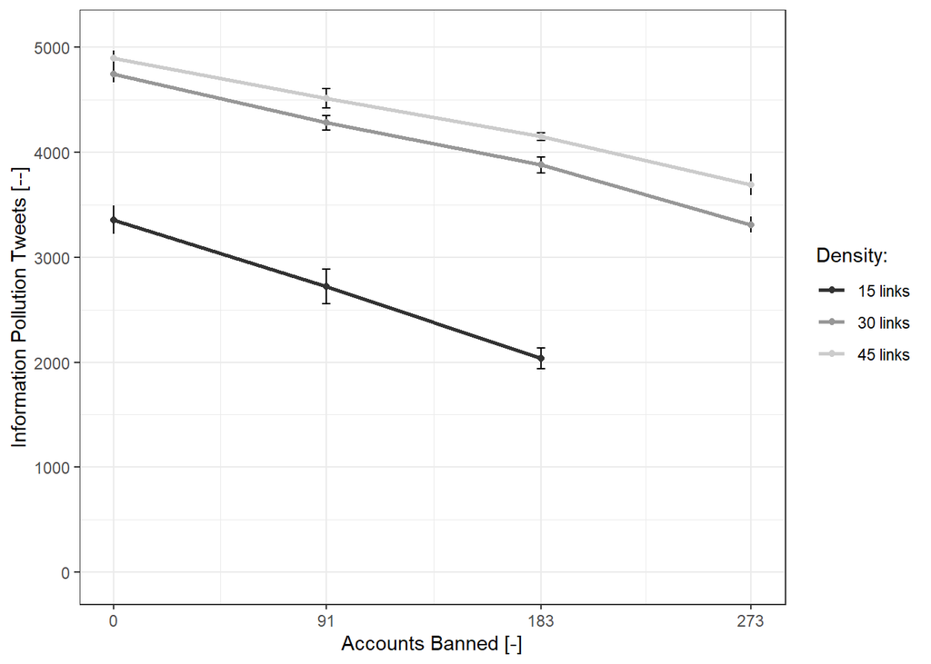

```r
##### creating plots -----------------------------------------------------------------
## "Real-Life" Network Only
# Preparing Data
data04 <- data02 %>%
  filter(., dens %in% "real") %>%
  filter(., no_del >= 183) %>%
  mutate(., dat_bas = "all")
data05 <- data03 %>%
  filter(., dens %in% "real") %>%
  mutate(., dat_bas = "365_oly")
data06 <- data04 %>%
  rbind(., data05)

# rendering, showing and saving plot
gg01 <- data06 %>%
        ggplot( aes(x = no_del,
                    group = dat_bas,
                    color = dat_bas) ) +

        geom_line(aes(y = mn_newip ) ) +

        geom_errorbar(aes(ymin = mn_newip - sd_newip,
                          ymax = mn_newip + sd_newip),
                      colour = "black",
                      width = 5.0,
                      size = 0.5) +

        geom_point(aes(y = mn_newip),
                       size = 1.5) +

        scale_y_continuous(name ="Information Pollution Tweets [-]",
                           limits = c(-50, 3550)) +

        scale_x_continuous(name = "Accounts Banned [-]",
                           breaks = c(0, 91, 183, 273),
                           limits = c(-1, 274)) +

        scale_color_grey(name = "Runs:",
                         labels = c("365 days", "Less than\n365 days")) +

        theme_bw()

# saving plot
gg01 %>%
  ggsave(., filename = "./PlotsTables/plt_ban_noip10_lstwt07_real_allobs_01.png",
      units = "cm",
      dpi = "retina",
      height = 8,
      width = 14)


#### "Artificial Network" 365 days Only ---------------------------------------
# rendering
gg02 <- data03 %>%

        filter(., dens %in% c("sim_15", "sim_30", "sim_45")) %>%

        ggplot( aes(x = no_del,
                    group = dens,
                    color = dens) ) +

        geom_line(aes(y = mn_newip ),
                      size = 1.0) +

        geom_errorbar(aes(ymin = mn_newip - sd_newip,
                          ymax = mn_newip + sd_newip),
                          colour = "black",
                          width = 3.5,
                          size = 0.5) +

        geom_point(aes(y = mn_newip),
                       size = 1.5) +

        scale_y_continuous(name ="Information Pollution Tweets [--]",
                           limits = c(-50, 5100)) +

        scale_x_continuous(name = "Accounts Banned [-]",
                           breaks = c(0, 91, 183, 273),
                           limits = c(-1, 274)) +

        scale_color_grey(name = "Density:",
                         labels = c("15 links", "30 links", "45 links")) +

        theme_bw()

# showing plot
gg02
```

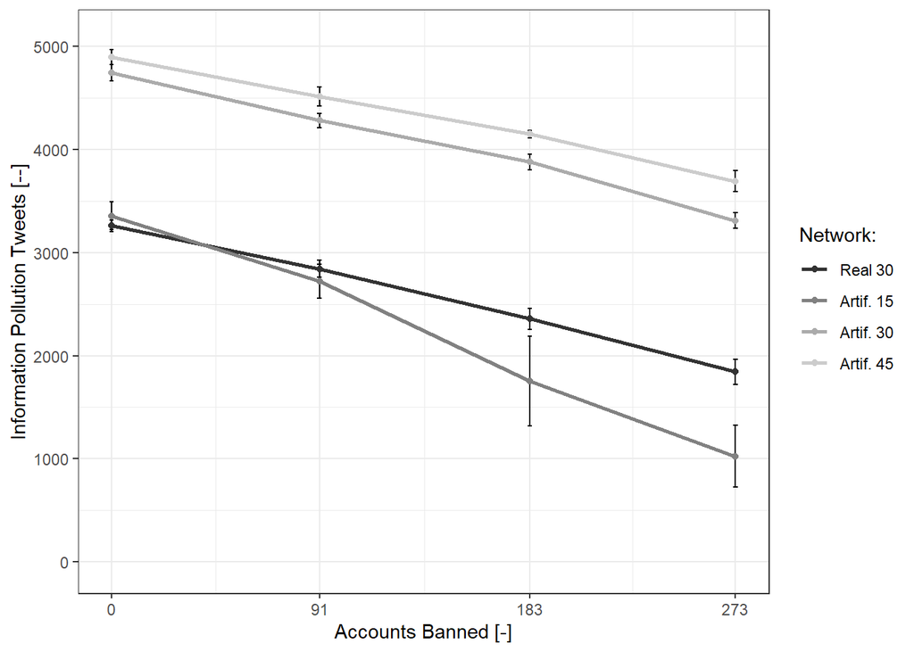

```r
# saving plot
gg02 %>%
  ggsave(., filename = "./PlotsTables/plt_ban_noip10_lstwt07_artif_365_01.png",
      units = "cm",
      dpi = "retina",
      height = 8,
      width = 14)


#### Real and Artificial Networks, All Observations ---------------------------------------
# rendering
gg03 <- data02 %>%

        ggplot( aes(x = no_del,
                    group = dens,
                    color = dens) ) +

        geom_line(aes(y = mn_newip ),
                      size = 1.0) +

        geom_errorbar(aes(ymin = mn_newip - sd_newip,
                          ymax = mn_newip + sd_newip),
                          colour = "black",
                          width = 2.0,
                          size = 0.5) +

        geom_point(aes(y = mn_newip),
                       size = 1.5) +

        scale_y_continuous(name ="Information Pollution Tweets [--]",
                           limits = c(-50, 5100)) +

        scale_x_continuous(name = "Accounts Banned [-]",
                           breaks = c(0, 91, 183, 273),
                           limits = c(-1, 274)) +

        scale_color_grey(name = "Network:",
                         labels = c("Real 30", "Artif. 15", "Artif. 30", "Artif. 45")) +

        theme_bw()

# showing plot
gg03
```

```r
# saving plot
gg03 %>%
  ggsave(., filename = "./PlotsTables/plt_ban_noip10_lstwt07_all_allobs_01.png",
      units = "cm",
      dpi = "retina",
      height = 8,
      width = 14)


## removing auxillary variables
rm(col_lab, n_row)
rm(list= ls(pattern= "data"))
rm(list= ls(pattern= "vct"))
rm(list= ls(pattern= "res"))
rm(list= ls(pattern= "gg"))
```